# 08_Robustnessanalyses

Chiara Draxler

24 1 2022

#Introduction for working code:

0. Download the Code from Github. The new downloaded folder hc_switch_cccu-main contains the R project, Rmd Code, created data frames, knitted Html Code, Figures as .pdf and.jpg, Preregistered synthetic Code, and a folder to store the downloaded RData called RData.

Name the folder appropriately (when downloading the code from GitHub the folder will be hc_switch_cccu-main).

1. Download data from https://www.icpsr.umich.edu/web/DSDR/studies/37067/datadocumentation

Attention! The downloaded project from GitHub does not contain any data files!

–> Click on Download, then select R, then follow the login –> store data in the folder specific to the R project in an extra sub-folder called RData (i.e., hc_switch_cccu-main - > RData). If you downloaded the code from GitHub, the RData folder will be already in the hc_switch_cccu-main projects folder.

–> Within the RData folder store data for wave 1 in DS0001, for wave 2 in DS0002 and so on (i.e., hc_switch_cccu-main - > RData -> DS0001 ). If you downloaded the code from GitHub, the relevant folders will be already there.

–> name the Rdata files according to the wave:

Wave 1: 37067-0001-Data (i.e., hc_switch_cccu-main - > RData -> DS0001 -> 37067-0001-Data.rda )

Wave 2: 37067-0002-Data (i.e., hc_switch_cccu-main - > RData -> DS0002 -> 37067-0002-Data.rda )

Wave 3: 37067-0003-Data (i.e., hc_switch_cccu-main - > RData -> DS0003 -> 37067-0003-Data.rda )

Wave 4: 37067-0004-Data (i.e., hc_switch_cccu-main - > RData -> DS0004 -> 37067-0004-Data.rda )

–> attention to the .rda ending when loading the data into R!

2. make sure to install all relevant packages before running the code!

All relevant packages and versions can be seen in the section “Analyses”

3. run the code according to the defined order beginning with 01_ (or 0 if you want to have a look at the synthetic data) and ending with 09_ so that all data frames are created appropriately
4. Run the Code :) #1. Load Data

```r
#MA
load("cccu_R1.RData")
length(unique(cccu_R1$CASEID)) #women
```

```
## [1] 1907
```

```r
load("cccu_R2.RData")
length(unique(cccu_R2$CASEID)) #women
```

```
## [1] 1993
```

```r
load("cccu_R3.RData")
length(unique(cccu_R3$CASEID)) #women
```

```
## [1] 1984
```

```r
#SA
load("cccu_R1_s.RData")
length(unique(cccu_R1_s$CASEID)) #women
```

```
## [1] 1131
```

```r
load("cccu_R2_s.RData")
length(unique(cccu_R2_s$CASEID)) #women
```

```
## [1] 1226
```

```r
load("cccu_R3_s.RData")
length(unique(cccu_R3_s$CASEID)) #women
```

```
## [1] 1224
```

#2. Load Packages

```r
library(formr)
library(effects)
library(EValue)
library(lme4)
library(psych)
library(dplyr)
library(tidyverse)
library(patchwork)
library(marginaleffects)
options(scipen=999)
```

#3. R1:Analysis of Robustness 1

##Main Analysis

###3.1 Model 1: basic model

```r
R1_ma_1 <- glmer(switch ~ hc + (1| CASEID), family = binomial, data = cccu_R1, control=glmerControl(optimizer="bobyqa"))

summary(R1_ma_1)
```

```
## Generalized linear mixed model fit by maximum likelihood (Laplace
##   Approximation) [glmerMod]
##  Family: binomial  ( logit )
## Formula: switch ~ hc + (1 | CASEID)
##    Data: cccu_R1
## Control: glmerControl(optimizer = "bobyqa")
##
##      AIC      BIC   logLik deviance df.resid
##   2491.6   2510.2  -1242.8   2485.6     3553
##
## Scaled residuals:
##      Min       1Q   Median       3Q      Max
## -1.61565 -0.03290 -0.03198 -0.01842  2.38550
##
## Random effects:
##  Groups Name        Variance Std.Dev.
##  CASEID (Intercept) 62.83    7.927
## Number of obs: 3556, groups:  CASEID, 1907
##
## Fixed effects:
##             Estimate Std. Error z value             Pr(>|z|)
## (Intercept)  -6.6925     0.3409 -19.634 < 0.0000000000000002 ***
## hcnon_hc     -1.2324     0.2314  -5.327         0.0000000998 ***
## ---
## Signif. codes:  0 '***' 0.001 '**' 0.01 '*' 0.05 '.' 0.1 ' ' 1
##
## Correlation of Fixed Effects:
##          (Intr)
## hcnon_hc -0.196
```

```r
confint(R1_ma_1, method = "Wald", level = .997)
```

```
##                0.15 %    99.85 %
## .sig01             NA         NA
## (Intercept) -7.704059 -5.6808892
## hcnon_hc    -1.919022 -0.5458391
```

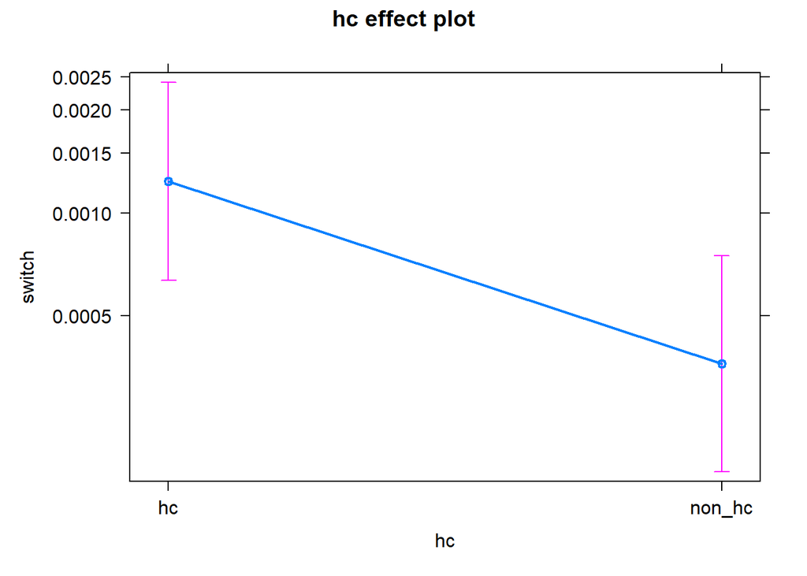

```r
plot(allEffects(R1_ma_1))
```

###3.2 Model 2: including directly with contraceptive method associated predictors

```r
R1_ma_2 <- glmer(switch ~ hc*contra_satis + (1| CASEID), family = binomial, data = cccu_R1, control=glmerControl(optimizer="bobyqa"))

summary(R1_ma_2)
```

```
## Generalized linear mixed model fit by maximum likelihood (Laplace
##   Approximation) [glmerMod]
##  Family: binomial  ( logit )
## Formula: switch ~ hc * contra_satis + (1 | CASEID)
##    Data: cccu_R1
## Control: glmerControl(optimizer = "bobyqa")
##
##      AIC      BIC   logLik deviance df.resid
##   2481.6   2512.5  -1235.8   2471.6     3551
##
## Scaled residuals:
##      Min       1Q   Median       3Q      Max
## -2.32480 -0.03084 -0.02876 -0.01782  3.03505
##
## Random effects:
##  Groups Name        Variance Std.Dev.
##  CASEID (Intercept) 59.01    7.682
## Number of obs: 3556, groups:  CASEID, 1907
##
## Fixed effects:
##                       Estimate Std. Error z value    Pr(>|z|)
## (Intercept)            -4.0860     0.8070  -5.063 0.000000412 ***
## hcnon_hc               -2.5394     1.0481  -2.423    0.015400 *
## contra_satis           -0.7039     0.2017  -3.490    0.000483 ***
## hcnon_hc:contra_satis   0.3560     0.3092   1.151    0.249552
## ---
## Signif. codes:  0 '***' 0.001 '**' 0.01 '*' 0.05 '.' 0.1 ' ' 1
##
## Correlation of Fixed Effects:
##             (Intr) hcnn_h cntr_s
## hcnon_hc    -0.619
## contra_sats -0.898  0.647
## hcnn_hc:cn_  0.586 -0.975 -0.633
```

```r
confint(R1_ma_2, method = "Wald", level = .997)
```

```
##                           0.15 %    99.85 %
## .sig01                        NA         NA
## (Intercept)           -6.4809668 -1.6909975
## hcnon_hc              -5.6500206  0.5711253
## contra_satis          -1.3024388 -0.1053361
## hcnon_hc:contra_satis -0.5615842  1.2736145
```

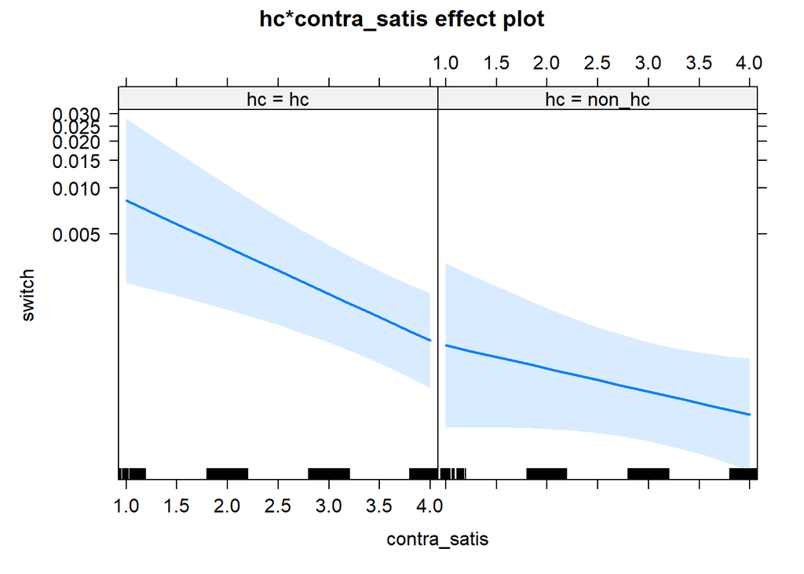

```r
plot(allEffects(R1_ma_2))
```

###3.3 Model 3: including not directly with contraceptive method associated predictors

```r
R1_ma_3 <- glmer(switch ~ hc * contra_satis + hc * sexual_satisfaction + hc * sex_freq + (1| CASEID), family = binomial, data = cccu_R1, control=glmerControl(optimizer="bobyqa"))

summary(R1_ma_3)
```

```
## Generalized linear mixed model fit by maximum likelihood (Laplace
##   Approximation) [glmerMod]
##  Family: binomial  ( logit )
## Formula: switch ~ hc * contra_satis + hc * sexual_satisfaction + hc *
##     sex_freq + (1 | CASEID)
##    Data: cccu_R1
## Control: glmerControl(optimizer = "bobyqa")
##
##      AIC      BIC   logLik deviance df.resid
##   2482.3   2562.6  -1228.1   2456.3     3543
##
## Scaled residuals:
##      Min       1Q   Median       3Q      Max
## -2.54671 -0.03404 -0.02471 -0.01631  3.06023
##
## Random effects:
##  Groups Name        Variance Std.Dev.
##  CASEID (Intercept) 61.54    7.845
## Number of obs: 3556, groups:  CASEID, 1907
##
## Fixed effects:
##                                   Estimate Std. Error z value   Pr(>|z|)
## (Intercept)                       -5.40988    1.11814  -4.838 0.00000131 ***
## hcnon_hc                           0.16096    1.45198   0.111   0.911729
## contra_satis                      -0.74638    0.20808  -3.587   0.000335 ***
## sexual_satisfaction                0.36870    0.14837   2.485   0.012951 *
## sex_freq2-5 times                 -0.37958    0.55644  -0.682   0.495141
## sex_freq6-10 times                -0.50599    0.59153  -0.855   0.392334
## sex_freq11 or more times          -1.04515    0.65361  -1.599   0.109810
## hcnon_hc:contra_satis              0.45001    0.32278   1.394   0.163267
## hcnon_hc:sexual_satisfaction      -0.56189    0.21461  -2.618   0.008840 **
## hcnon_hc:sex_freq2-5 times        -0.70684    0.84526  -0.836   0.403015
## hcnon_hc:sex_freq6-10 times       -0.08126    0.89868  -0.090   0.927949
## hcnon_hc:sex_freq11 or more times  0.94004    0.96922   0.970   0.332098
## ---
## Signif. codes:  0 '***' 0.001 '**' 0.01 '*' 0.05 '.' 0.1 ' ' 1
##
## Correlation of Fixed Effects:
##             (Intr) hcnn_h cntr_s sxl_st s_2-5t s_6-1t s_1omt hcnn_hc:c_
## hcnon_hc    -0.660
## contra_sats -0.571  0.425
## sxl_stsfctn -0.528  0.314 -0.143
## sx_frq2-5tm -0.353  0.266  0.005 -0.112
## sx_frq6-10t -0.293  0.219 -0.001 -0.185  0.855
## sx_frq11omt -0.228  0.174  0.010 -0.226  0.771  0.776
## hcnn_hc:cn_  0.360 -0.586 -0.636  0.102  0.003  0.015  0.011
## hcnn_hc:sx_  0.312 -0.486  0.102 -0.578  0.068  0.106  0.135 -0.203
## hcnn_:_2-5t  0.292 -0.410 -0.035  0.055 -0.630 -0.539 -0.486  0.026
## hcn_:_6-10t  0.209 -0.284 -0.007  0.100 -0.524 -0.606 -0.466 -0.017
## hcn_:_11omt  0.173 -0.234 -0.012  0.121 -0.483 -0.476 -0.604 -0.025
##             hcnn_hc:s_ h_:_2t h_:_6t
## hcnon_hc
## contra_sats
## sxl_stsfctn
## sx_frq2-5tm
## sx_frq6-10t
## sx_frq11omt
## hcnn_hc:cn_
## hcnn_hc:sx_
## hcnn_:_2-5t -0.126
## hcn_:_6-10t -0.229      0.791
## hcn_:_11omt -0.248      0.729  0.723
```

```r
confint(R1_ma_3, method = "Wald", level = .997)
```

```
##                                        0.15 %    99.85 %
## .sig01                                     NA         NA
## (Intercept)                       -8.72821682 -2.0915445
## hcnon_hc                          -4.14812941  4.4700549
## contra_satis                      -1.36390140 -0.1288509
## sexual_satisfaction               -0.07160518  0.8090137
## sex_freq2-5 times                 -2.03096389  1.2718008
## sex_freq6-10 times                -2.26149835  1.2495166
## sex_freq11 or more times          -2.98488365  0.8945868
## hcnon_hc:contra_satis             -0.50792267  1.4079498
## hcnon_hc:sexual_satisfaction      -1.19879683  0.0750219
## hcnon_hc:sex_freq2-5 times        -3.21534831  1.8016583
## hcnon_hc:sex_freq6-10 times       -2.74832177  2.5857928
## hcnon_hc:sex_freq11 or more times -1.93635156  3.8164400
```

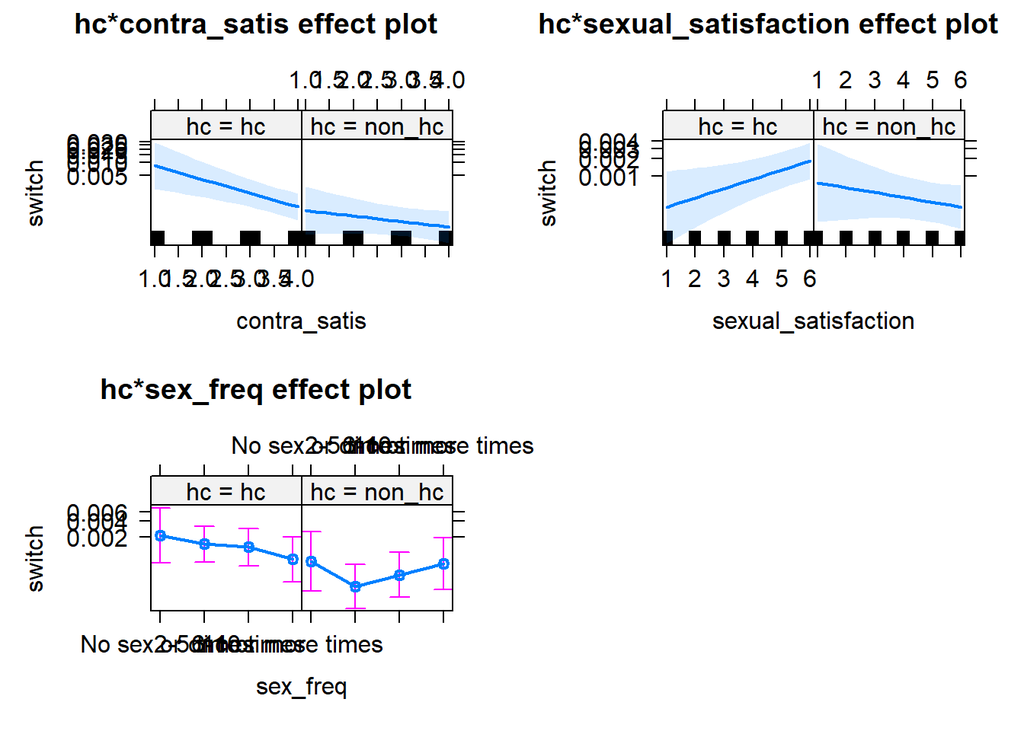

```r
plot(allEffects(R1_ma_3))
```

###3.4 Model 4: Controlling for observed selection effects

```r
#filter for first measurement occasion
length(unique(cccu_R1$CASEID))
```

```
## [1] 1907
```

```r
cccu_R1_sens = cccu_R1 %>%
  group_by(CASEID) %>%
  arrange(WAVE) %>%
  mutate(count = row_number()) %>%
  ungroup()

cccu_R1_sens = cccu_R1_sens %>%
  filter(count == 1)

table(cccu_R1_sens$WAVE)
```

```
##
##   t1   t2   t3   t4
## 1626  210   71    0
```

```r
#repeat model 3 for sensitivity analyses
R1_m3_lm = glm(switch ~ hc * contra_satis + hc * sexual_satisfaction +  hc * sex_freq,
          family = binomial,
          data = cccu_R1_sens)
summary(R1_m3_lm)
```

```
##
## Call:
## glm(formula = switch ~ hc * contra_satis + hc * sexual_satisfaction +
##     hc * sex_freq, family = binomial, data = cccu_R1_sens)
##
## Deviance Residuals:
##     Min       1Q   Median       3Q      Max
## -1.1732  -0.5797  -0.4742  -0.3978   2.3801
##
## Coefficients:
##                                    Estimate Std. Error z value    Pr(>|z|)
## (Intercept)                        0.004434   0.575412   0.008      0.9939
## hcnon_hc                          -2.205868   0.932108  -2.367      0.0180 *
## contra_satis                      -0.562839   0.111423  -5.051 0.000000439 ***
## sexual_satisfaction                0.142897   0.082892   1.724      0.0847 .
## sex_freq2-5 times                 -0.308875   0.305094  -1.012      0.3114
## sex_freq6-10 times                -0.308917   0.321744  -0.960      0.3370
## sex_freq11 or more times          -0.541454   0.346978  -1.560      0.1186
## hcnon_hc:contra_satis              0.432173   0.192752   2.242      0.0250 *
## hcnon_hc:sexual_satisfaction      -0.047009   0.142819  -0.329      0.7420
## hcnon_hc:sex_freq2-5 times         0.034752   0.503476   0.069      0.9450
## hcnon_hc:sex_freq6-10 times       -0.039453   0.546831  -0.072      0.9425
## hcnon_hc:sex_freq11 or more times  0.561387   0.594455   0.944      0.3450
## ---
## Signif. codes:  0 '***' 0.001 '**' 0.01 '*' 0.05 '.' 0.1 ' ' 1
##
## (Dispersion parameter for binomial family taken to be 1)
##
##     Null deviance: 1511.6  on 1906  degrees of freedom
## Residual deviance: 1449.9  on 1895  degrees of freedom
## AIC: 1473.9
##
## Number of Fisher Scoring iterations: 5
```

```r
confint(R1_m3_lm, method = "Wald", level = .997)
```

```
##                                         0.2 %     99.8 %
## (Intercept)                       -1.75139180  1.6803775
## hcnon_hc                          -5.07681222  0.4890707
## contra_satis                      -0.89415138 -0.2289516
## sexual_satisfaction               -0.09564741  0.3979983
## sex_freq2-5 times                 -1.17674950  0.6568468
## sex_freq6-10 times                -1.23347423  0.6984657
## sex_freq11 or more times          -1.55343218  0.5287141
## hcnon_hc:contra_satis             -0.12977411  1.0193600
## hcnon_hc:sexual_satisfaction      -0.46097966  0.3918930
## hcnon_hc:sex_freq2-5 times        -1.43346672  1.6059244
## hcnon_hc:sex_freq6-10 times       -1.65127986  1.6412788
## hcnon_hc:sex_freq11 or more times -1.21115034  2.3647207
```

```r
R1_ma_4 <- glm(switch ~ hc * contra_satis + hc * sexual_satisfaction + hc * sex_freq + hc *AGE + hc *DEGREE_recode + hc *POVRATE + hc *HLTHPROB_recode + hc *MEDPROB_recode +  hc *GAPINS_recode + hc *TYPEINS_recode + hc *NKIDS_t1 +  hc *pregnant_between_waves + hc *had_baby_between_waves+ hc *Avoid_r + hc *FEELPG_recode + hc *rel_dur_factor, family = binomial, data = cccu_R1_sens)

summary(R1_ma_4)
```

```
##
## Call:
## glm(formula = switch ~ hc * contra_satis + hc * sexual_satisfaction +
##     hc * sex_freq + hc * AGE + hc * DEGREE_recode + hc * POVRATE +
##     hc * HLTHPROB_recode + hc * MEDPROB_recode + hc * GAPINS_recode +
##     hc * TYPEINS_recode + hc * NKIDS_t1 + hc * pregnant_between_waves +
##     hc * had_baby_between_waves + hc * Avoid_r + hc * FEELPG_recode +
##     hc * rel_dur_factor, family = binomial, data = cccu_R1_sens)
##
## Deviance Residuals:
##     Min       1Q   Median       3Q      Max
## -1.9904  -0.5530  -0.3903  -0.2163   3.3275
##
## Coefficients: (1 not defined because of singularities)
##                                                             Estimate
## (Intercept)                                              -11.8397225
## hcnon_hc                                                  -0.6794175
## contra_satis                                              -0.5295259
## sexual_satisfaction                                        0.1201478
## sex_freq2-5 times                                         -0.2022384
## sex_freq6-10 times                                        -0.1208778
## sex_freq11 or more times                                  -0.4520407
## AGE                                                        0.0307284
## DEGREE_recode5th/6th grade                                -2.0986472
## DEGREE_recode7th/8th grade                                12.5421368
## DEGREE_recode9th grade                                    -2.8596188
## DEGREE_recode10th grade                                   13.7706055
## DEGREE_recode11th grade                                   12.0617409
## DEGREE_recode12th grade / no diploma                      13.0426587
## DEGREE_recodehigh school diploma or equivalent            12.7835154
## DEGREE_recodesome college, no degree                      12.8939295
## DEGREE_recodeassociate degree                             12.0875373
## DEGREE_recodebachelors degree                             12.8010275
## DEGREE_recodemasters degree                               12.8080206
## DEGREE_recodeprofessional or doctoral degree              13.0110040
## POVRATE                                                   -0.0002077
## HLTHPROB_recodeYes                                         0.1484307
## MEDPROB_recodeYes                                         -0.2695240
## GAPINS_recodeYes                                          -0.1167516
## TYPEINS_recodeYes                                         -0.4288675
```

[output cut: 188 more lines]

```
## hcnon_hc:FEELPG_recode                                     0.009858 **
## hcnon_hc:rel_dur_factor0q-25q                              0.499775
## hcnon_hc:rel_dur_factor26q-50q                             0.114974
## hcnon_hc:rel_dur_factor51q-75q                             0.822859
## hcnon_hc:rel_dur_factor76q-100q                            0.383767
## ---
## Signif. codes:  0 '***' 0.001 '**' 0.01 '*' 0.05 '.' 0.1 ' ' 1
##
## (Dispersion parameter for binomial family taken to be 1)
##
##     Null deviance: 1511.6  on 1906  degrees of freedom
## Residual deviance: 1284.1  on 1836  degrees of freedom
## AIC: 1426.1
##
## Number of Fisher Scoring iterations: 15
```

```r
confint(R1_ma_4, parm = c("(Intercept)",
                                               "hcnon_hc",
                                               "contra_satis",
                                               "sexual_satisfaction",
                                               "sex_freq2-5 times", "sex_freq6-10 times",
                                               "sex_freq11 or more times",
                                               "hcnon_hc:contra_satis",
                                               "hcnon_hc:sexual_satisfaction",
                                               "hcnon_hc:sex_freq2-5 times",
                                               "hcnon_hc:sex_freq6-10 times",
                                               "hcnon_hc:sex_freq11 or more times"), method = "Wald", level = .997)
```

[output not shown]

[output not shown]

[output cut: 34 more lines]

[output not shown]

```
##                                        0.2 %      99.8 %
## (Intercept)                               NA 825.8333527
## hcnon_hc                          -7.3227181   5.8610023
## contra_satis                      -0.8930819  -0.1640039
## sexual_satisfaction               -0.1321622   0.3882971
## sex_freq2-5 times                 -1.1370591   0.8267161
## sex_freq6-10 times                -1.1168675   0.9546878
## sex_freq11 or more times          -1.5575163   0.7013354
## hcnon_hc:contra_satis             -0.3624929   0.8934548
## hcnon_hc:sexual_satisfaction      -0.3957834   0.5389146
## hcnon_hc:sex_freq2-5 times        -1.4270643   1.8490064
## hcnon_hc:sex_freq6-10 times       -1.6800131   1.9298282
## hcnon_hc:sex_freq11 or more times -1.3397111   2.5545230
```

```
## Note:
##   1 value in the hc*DEGREE_recode effect are not estimable
```

[figure not shown]

```r
plot(allEffects(R1_ma_4))
```

###R1: Average marginal effects ####m1

```r
#average marginal effect
ame <- marginaleffects(R1_ma_1)
summary(ame)
```

```
##   Term    Contrast   Effect Std. Error z value       Pr(>|z|)   2.5 %   97.5 %
## 1   hc non_hc - hc -0.05048   0.009143  -5.521 0.000000033779 -0.0684 -0.03256
##
## Model type:  glmerMod
## Prediction type:  response
```

####m2

```r
#average marginal effect
ame <- marginaleffects(R1_ma_2)
summary(ame)
```

```
##           Term    Contrast   Effect Std. Error z value        Pr(>|z|)    2.5 %
## 1           hc non_hc - hc -0.05406   0.009141  -5.915 0.0000000033285 -0.07198
## 2 contra_satis       dY/dX -0.02504   0.006491  -3.857      0.00011497 -0.03776
##     97.5 %
## 1 -0.03615
## 2 -0.01231
##
## Model type:  glmerMod
## Prediction type:  response
```

```r
R1_m2_hc_only <- glmer(switch ~ contra_satis + (1| CASEID),
                    family = binomial,
                    data = cccu_R1%>% filter(hc == "hc"),
                    control=glmerControl(optimizer="bobyqa"))
ame <- marginaleffects(R1_m2_hc_only)
summary(ame)
```

```
##           Term   Effect Std. Error z value       Pr(>|z|)    2.5 %  97.5 %
## 1 contra_satis -0.06278    0.01132  -5.547 0.000000029013 -0.08497 -0.0406
##
## Model type:  glmerMod
## Prediction type:  response
```

```r
R1_m2_nonhc_only <- glmer(switch ~ contra_satis + (1| CASEID),
                    family = binomial,
                    data = cccu_R1 %>% filter(hc == "non_hc"),
                    control=glmerControl(optimizer="bobyqa"))
ame <- marginaleffects(R1_m2_nonhc_only)
summary(ame)
```

```
##           Term   Effect Std. Error z value Pr(>|z|)    2.5 %   97.5 %
## 1 contra_satis -0.00113   0.005538 -0.2041  0.83825 -0.01198 0.009723
##
## Model type:  glmerMod
## Prediction type:  response
```

####m3

```r
#average marginal effect
ame <- marginaleffects(R1_ma_3)
summary(ame)
```

```
##                  Term                          Contrast    Effect Std. Error
## 1                  hc                       non_hc - hc -0.053601   0.009042
## 2        contra_satis                             dY/dX -0.025192   0.006516
## 3 sexual_satisfaction                             dY/dX  0.008526   0.004965
## 4            sex_freq        2-5 times - No sex or once -0.023843   0.017913
## 5            sex_freq       6-10 times - No sex or once -0.021817   0.019490
## 6            sex_freq 11 or more times - No sex or once -0.031423   0.021538
##   z value        Pr(>|z|)     2.5 %   97.5 %
## 1  -5.928 0.0000000030658 -0.071323 -0.03588
## 2  -3.866      0.00011051 -0.037963 -0.01242
## 3   1.717      0.08593892 -0.001205  0.01826
## 4  -1.331      0.18318852 -0.058952  0.01127
## 5  -1.119      0.26295195 -0.060016  0.01638
## 6  -1.459      0.14457036 -0.073636  0.01079
##
## Model type:  glmerMod
## Prediction type:  response
```

```r
R1_m3_hc_only <-glmer(switch ~ contra_satis + sexual_satisfaction + sex_freq + (1| CASEID),
                    family = binomial,
                    data = cccu_R1%>% filter(hc == "hc"),
                    control=glmerControl(optimizer="bobyqa"))
ame <- marginaleffects(R1_m3_hc_only)
summary(ame)
```

```
##                  Term                          Contrast    Effect Std. Error
## 1        contra_satis                             dY/dX -0.065396   0.011379
## 2 sexual_satisfaction                             dY/dX  0.019945   0.007983
## 3            sex_freq        2-5 times - No sex or once -0.005711   0.035501
## 4            sex_freq       6-10 times - No sex or once -0.025008   0.036716
## 5            sex_freq 11 or more times - No sex or once -0.043165   0.037841
##   z value        Pr(>|z|)     2.5 %   97.5 %
## 1 -5.7470 0.0000000090859 -0.087699 -0.04309
## 2  2.4984        0.012474  0.004299  0.03559
## 3 -0.1609        0.872196 -0.075291  0.06387
## 4 -0.6811        0.495788 -0.096970  0.04695
## 5 -1.1407        0.253988 -0.117331  0.03100
##
## Model type:  glmerMod
## Prediction type:  response
```

```r
R1_m3_nonhc_only <- glmer(switch ~ contra_satis + sexual_satisfaction +   sex_freq + (1| CASEID),
                    family = binomial,
                    data = cccu_R1 %>% filter(hc == "non_hc"),
                    control=glmerControl(optimizer="bobyqa"))
ame <- marginaleffects(R1_m3_nonhc_only)
summary(ame)
```

```
##                  Term                          Contrast     Effect Std. Error
## 1        contra_satis                             dY/dX -0.0005487   0.005604
## 2 sexual_satisfaction                             dY/dX -0.0022447   0.003912
## 3            sex_freq        2-5 times - No sex or once -0.0155491   0.012347
## 4            sex_freq       6-10 times - No sex or once -0.0137693   0.014194
## 5            sex_freq 11 or more times - No sex or once  0.0004432   0.012111
##    z value Pr(>|z|)     2.5 %   97.5 %
## 1 -0.09790  0.92201 -0.011533 0.010435
## 2 -0.57378  0.56612 -0.009912 0.005423
## 3 -1.25932  0.20791 -0.039749 0.008651
## 4 -0.97009  0.33200 -0.041589 0.014050
## 5  0.03659  0.97081 -0.023295 0.024181
##
## Model type:  glmerMod
## Prediction type:  response
```

####m4

```r
ame <- marginaleffects(R1_m3_lm)
summary(ame)
```

```
##                  Term                          Contrast   Effect Std. Error
## 1                  hc                       non_hc - hc -0.10072   0.015833
## 2        contra_satis                             dY/dX -0.04857   0.010100
## 3 sexual_satisfaction                             dY/dX  0.01449   0.007622
## 4            sex_freq        2-5 times - No sex or once -0.03704   0.032392
## 5            sex_freq       6-10 times - No sex or once -0.03941   0.033918
## 6            sex_freq 11 or more times - No sex or once -0.04328   0.036188
##   z value         Pr(>|z|)      2.5 %   97.5 %
## 1  -6.361 0.00000000019989 -0.1317565 -0.06969
## 2  -4.809 0.00000151699098 -0.0683684 -0.02878
## 3   1.901         0.057291 -0.0004488  0.02943
## 4  -1.143         0.252842 -0.1005271  0.02645
## 5  -1.162         0.245236 -0.1058919  0.02707
## 6  -1.196         0.231753 -0.1142036  0.02765
##
## Model type:  glm
## Prediction type:  response
```

```r
ame <- marginaleffects(R1_ma_4)
summary(ame)
```

```
##                      Term                                             Contrast
## 1                      hc                                          non_hc - hc
## 2            contra_satis                                                dY/dX
## 3     sexual_satisfaction                                                dY/dX
## 4                sex_freq                           2-5 times - No sex or once
## 5                sex_freq                          6-10 times - No sex or once
## 6                sex_freq                    11 or more times - No sex or once
## 7                     AGE                                                dY/dX
## 8           DEGREE_recode                     5th/6th grade - 1st to 4th grade
## 9           DEGREE_recode                     7th/8th grade - 1st to 4th grade
## 10          DEGREE_recode                         9th grade - 1st to 4th grade
## 11          DEGREE_recode                        10th grade - 1st to 4th grade
## 12          DEGREE_recode                        11th grade - 1st to 4th grade
## 13          DEGREE_recode           12th grade / no diploma - 1st to 4th grade
## 14          DEGREE_recode high school diploma or equivalent - 1st to 4th grade
```

[output cut: 99 more lines]

```r
R1_m4_hc_only <- glm(switch ~ contra_satis + sexual_satisfaction +  sex_freq +
                    AGE + DEGREE_recode + POVRATE +
                    HLTHPROB_recode + MEDPROB_recode +  GAPINS_recode +
                    TYPEINS_recode + NKIDS_t1 +  pregnant_between_waves +
                    had_baby_between_waves + Avoid_r + FEELPG_recode +
                    rel_dur_factor,
            family = binomial,
            data = cccu_R1_sens %>% filter(hc == "hc"))

ame <- marginaleffects(R1_m4_hc_only)
summary(ame)
```

```
##                      Term                                          Contrast
## 1            contra_satis                                             dY/dX
## 2     sexual_satisfaction                                             dY/dX
## 3                sex_freq                        2-5 times - No sex or once
## 4                sex_freq                       6-10 times - No sex or once
## 5                sex_freq                 11 or more times - No sex or once
## 6                     AGE                                             dY/dX
## 7           DEGREE_recode                     7th/8th grade - 5th/6th grade
## 8           DEGREE_recode                         9th grade - 5th/6th grade
## 9           DEGREE_recode                        10th grade - 5th/6th grade
## 10          DEGREE_recode                        11th grade - 5th/6th grade
## 11          DEGREE_recode           12th grade / no diploma - 5th/6th grade
## 12          DEGREE_recode high school diploma or equivalent - 5th/6th grade
## 13          DEGREE_recode           some college, no degree - 5th/6th grade
## 14          DEGREE_recode                  associate degree - 5th/6th grade
```

[output cut: 93 more lines]

```r
R1_m4_nonhc_only <- glm(switch ~ contra_satis + sexual_satisfaction +  sex_freq +
                    AGE + DEGREE_recode + POVRATE +
                    HLTHPROB_recode + MEDPROB_recode +  GAPINS_recode +
                    TYPEINS_recode + NKIDS_t1 +  pregnant_between_waves +
                    had_baby_between_waves + Avoid_r + FEELPG_recode +
                    rel_dur_factor,
            family = binomial,
            data = cccu_R1_sens %>% filter(hc == "non_hc"))

ame <- marginaleffects(R1_m4_nonhc_only)
summary(ame)
```

```
##                      Term                                             Contrast
## 1            contra_satis                                                dY/dX
## 2     sexual_satisfaction                                                dY/dX
## 3                sex_freq                           2-5 times - No sex or once
## 4                sex_freq                          6-10 times - No sex or once
## 5                sex_freq                    11 or more times - No sex or once
## 6                     AGE                                                dY/dX
## 7           DEGREE_recode                     5th/6th grade - 1st to 4th grade
## 8           DEGREE_recode                     7th/8th grade - 1st to 4th grade
## 9           DEGREE_recode                         9th grade - 1st to 4th grade
## 10          DEGREE_recode                        10th grade - 1st to 4th grade
## 11          DEGREE_recode                        11th grade - 1st to 4th grade
## 12          DEGREE_recode           12th grade / no diploma - 1st to 4th grade
## 13          DEGREE_recode high school diploma or equivalent - 1st to 4th grade
## 14          DEGREE_recode           some college, no degree - 1st to 4th grade
```

[output cut: 60 more lines]

## R1: Sub Analysis

###3.2 Model 2: including directly with contraceptive method associated predictors

DURATION and satisfaction!

```r
R1_sa_m2 <- glmer(switch ~ contra_satis * hc_dur + (1| CASEID), family = binomial, data = cccu_R1_s, control=glmerControl(optimizer="bobyqa"))
```

```
## boundary (singular) fit: see help('isSingular')
```

```r
summary(R1_sa_m2)
```

```
## Generalized linear mixed model fit by maximum likelihood (Laplace
##   Approximation) [glmerMod]
##  Family: binomial  ( logit )
## Formula: switch ~ contra_satis * hc_dur + (1 | CASEID)
##    Data: cccu_R1_s
## Control: glmerControl(optimizer = "bobyqa")
##
##      AIC      BIC   logLik deviance df.resid
##   1739.8   1767.9   -864.9   1729.8     2049
##
## Scaled residuals:
##     Min      1Q  Median      3Q     Max
## -1.1239 -0.4462 -0.3905 -0.3312  4.5556
##
## Random effects:
##  Groups Name        Variance Std.Dev.
##  CASEID (Intercept) 0        0
## Number of obs: 2054, groups:  CASEID, 1131
##
## Fixed effects:
##                     Estimate Std. Error z value  Pr(>|z|)
## (Intercept)          0.81115    0.49651   1.634    0.1023
## contra_satis        -0.57760    0.14296  -4.040 0.0000534 ***
## hc_dur              -0.10088    0.05149  -1.959    0.0501 .
## contra_satis:hc_dur  0.01587    0.01432   1.108    0.2679
## ---
## Signif. codes:  0 '***' 0.001 '**' 0.01 '*' 0.05 '.' 0.1 ' ' 1
##
## Correlation of Fixed Effects:
##             (Intr) cntr_s hc_dur
## contra_sats -0.974
## hc_dur      -0.792  0.762
## cntr_sts:h_  0.790 -0.797 -0.981
## optimizer (bobyqa) convergence code: 0 (OK)
## boundary (singular) fit: see help('isSingular')
```

```r
confint(R1_sa_m2, method = "Wald", level = .997)
```

```
##                          0.15 %     99.85 %
## .sig01                       NA          NA
## (Intercept)         -0.66236574  2.28466237
## contra_satis        -1.00186287 -0.15334030
## hc_dur              -0.25369205  0.05192484
## contra_satis:hc_dur -0.02664141  0.05838248
```

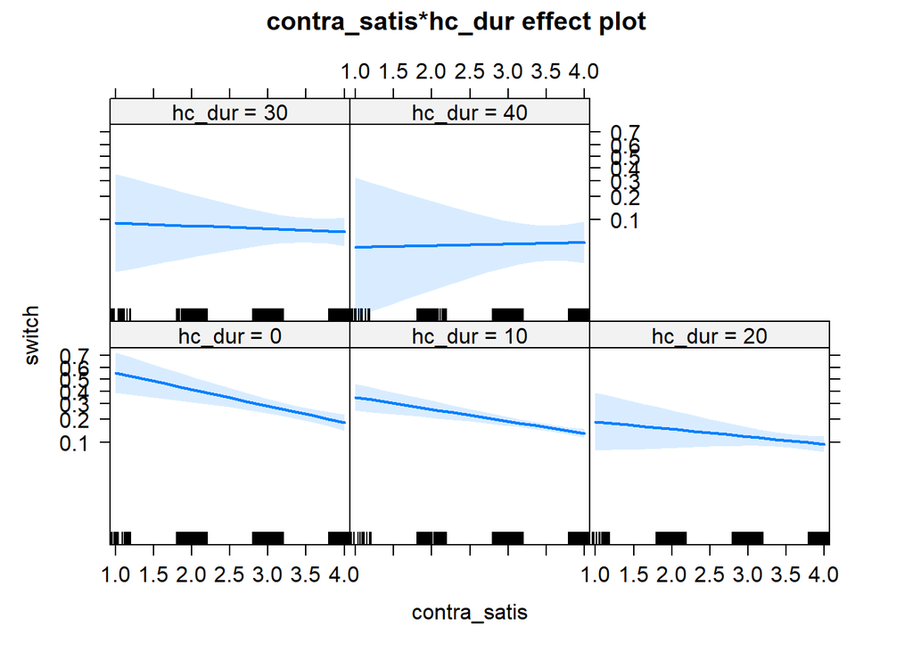

```r
plot(allEffects(R1_sa_m2))
```

###3.3 Model 3: including directly with contraceptive method associated predictors

DURATION and satisfaction!

```r
R1_sa_m3 <- glmer(switch ~ contra_satis * hc_dur +  sexual_satisfaction +  sex_freq + (1| CASEID), family = binomial, data = cccu_R1_s, control=glmerControl(optimizer="bobyqa"))
```

```
## boundary (singular) fit: see help('isSingular')
```

```r
summary(R1_sa_m3)
```

```
## Generalized linear mixed model fit by maximum likelihood (Laplace
##   Approximation) [glmerMod]
##  Family: binomial  ( logit )
## Formula: switch ~ contra_satis * hc_dur + sexual_satisfaction + sex_freq +
##     (1 | CASEID)
##    Data: cccu_R1_s
## Control: glmerControl(optimizer = "bobyqa")
##
##      AIC      BIC   logLik deviance df.resid
##   1737.7   1788.3   -859.8   1719.7     2045
##
## Scaled residuals:
##     Min      1Q  Median      3Q     Max
## -1.1173 -0.4437 -0.3811 -0.3185  4.5653
##
## Random effects:
##  Groups Name        Variance Std.Dev.
##  CASEID (Intercept) 0        0
## Number of obs: 2054, groups:  CASEID, 1131
##
## Fixed effects:
##                          Estimate Std. Error z value  Pr(>|z|)
## (Intercept)               0.17078    0.59298   0.288   0.77335
## contra_satis             -0.60717    0.14403  -4.216 0.0000249 ***
## hc_dur                   -0.10035    0.05145  -1.951   0.05111 .
## sexual_satisfaction       0.18130    0.06378   2.843   0.00448 **
## sex_freq2-5 times        -0.10137    0.25906  -0.391   0.69558
## sex_freq6-10 times       -0.23339    0.27245  -0.857   0.39165
## sex_freq11 or more times -0.42946    0.29073  -1.477   0.13963
## contra_satis:hc_dur       0.01586    0.01429   1.110   0.26697
## ---
## Signif. codes:  0 '***' 0.001 '**' 0.01 '*' 0.05 '.' 0.1 ' ' 1
##
## Correlation of Fixed Effects:
##             (Intr) cntr_s hc_dur sxl_st s_2-5t s_6-1t s_1omt
## contra_sats -0.758
## hc_dur      -0.643  0.759
## sxl_stsfctn -0.415 -0.089 -0.007
## sx_frq2-5tm -0.294 -0.034 -0.042 -0.117
## sx_frq6-10t -0.218 -0.050 -0.066 -0.194  0.846
## sx_frq11omt -0.206 -0.017 -0.032 -0.242  0.799  0.780
## cntr_sts:h_  0.639 -0.794 -0.981  0.011  0.045  0.062  0.035
## optimizer (bobyqa) convergence code: 0 (OK)
## boundary (singular) fit: see help('isSingular')
```

```r
confint(R1_sa_m3, method = "Wald", level = .997)
```

```
##                                0.15 %     99.85 %
## .sig01                             NA          NA
## (Intercept)              -1.589042245  1.93060177
## contra_satis             -1.034613781 -0.17972671
## hc_dur                   -0.253030123  0.05233158
## sexual_satisfaction      -0.007987473  0.37057869
## sex_freq2-5 times        -0.870206522  0.66746283
## sex_freq6-10 times       -1.041969148  0.57518030
## sex_freq11 or more times -1.292278426  0.43335056
## contra_satis:hc_dur      -0.026537738  0.05825323
```

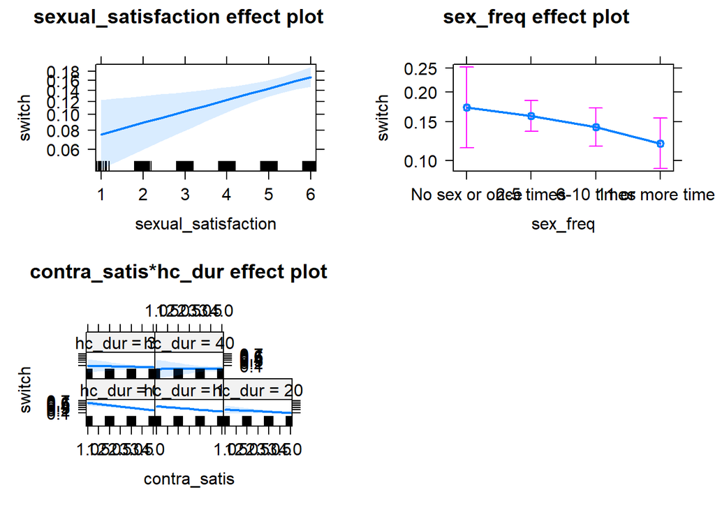

```r
plot(allEffects(R1_sa_m3))
```

###3.3 Model 4: including directly with contraceptive method associated predictors

DURATION and satisfaction!

```r
#filter for first measurement occasion
length(unique(cccu_R1_s$CASEID))
```

```
## [1] 1131
```

```r
cccu_R1_SA_sens = cccu_R1_s %>%
  group_by(CASEID) %>%
  arrange(WAVE) %>%
  mutate(count = row_number()) %>%
  ungroup()

cccu_R1_SA_sens = cccu_R1_SA_sens %>%
  filter(count == 1)

table(cccu_R1_SA_sens$WAVE)
```

```
##
##  t1  t2  t3  t4
## 935 140  56   0
```

```r
#repeating model 3 as linear model
R1_sa_m3_lm <- glm(switch ~ contra_satis* hc_dur  +  sexual_satisfaction +  sex_freq, family = binomial, data = cccu_R1_SA_sens)

summary(R1_sa_m3_lm)
```

```
##
## Call:
## glm(formula = switch ~ contra_satis * hc_dur + sexual_satisfaction +
##     sex_freq, family = binomial, data = cccu_R1_SA_sens)
##
## Deviance Residuals:
##     Min       1Q   Median       3Q      Max
## -1.3780  -0.6528  -0.5494  -0.4324   2.7868
##
## Coefficients:
##                          Estimate Std. Error z value Pr(>|z|)
## (Intercept)               0.62740    0.73407   0.855 0.392728
## contra_satis             -0.61201    0.17986  -3.403 0.000667 ***
## hc_dur                   -0.16339    0.10747  -1.520 0.128433
## sexual_satisfaction       0.18132    0.08011   2.263 0.023608 *
## sex_freq2-5 times        -0.39949    0.30011  -1.331 0.183147
## sex_freq6-10 times       -0.40420    0.31648  -1.277 0.201543
## sex_freq11 or more times -0.64308    0.33878  -1.898 0.057667 .
## contra_satis:hc_dur       0.02378    0.02952   0.806 0.420379
## ---
## Signif. codes:  0 '***' 0.001 '**' 0.01 '*' 0.05 '.' 0.1 ' ' 1
##
## (Dispersion parameter for binomial family taken to be 1)
##
##     Null deviance: 1070.6  on 1130  degrees of freedom
## Residual deviance: 1017.3  on 1123  degrees of freedom
## AIC: 1033.3
##
## Number of Fisher Scoring iterations: 4
```

```r
confint(R1_sa_m3_lm, method = "Wald", level = .997)
```

```
##                                0.2 %      99.8 %
## (Intercept)              -1.56288636  2.82797376
## contra_satis             -1.15712441 -0.07975438
## hc_dur                   -0.49564989  0.14759988
## sexual_satisfaction      -0.04911007  0.42795782
## sex_freq2-5 times        -1.25961440  0.54129308
## sex_freq6-10 times       -1.31867461  0.57876725
## sex_freq11 or more times -1.63469748  0.39532396
## contra_satis:hc_dur      -0.06300483  0.11364997
```

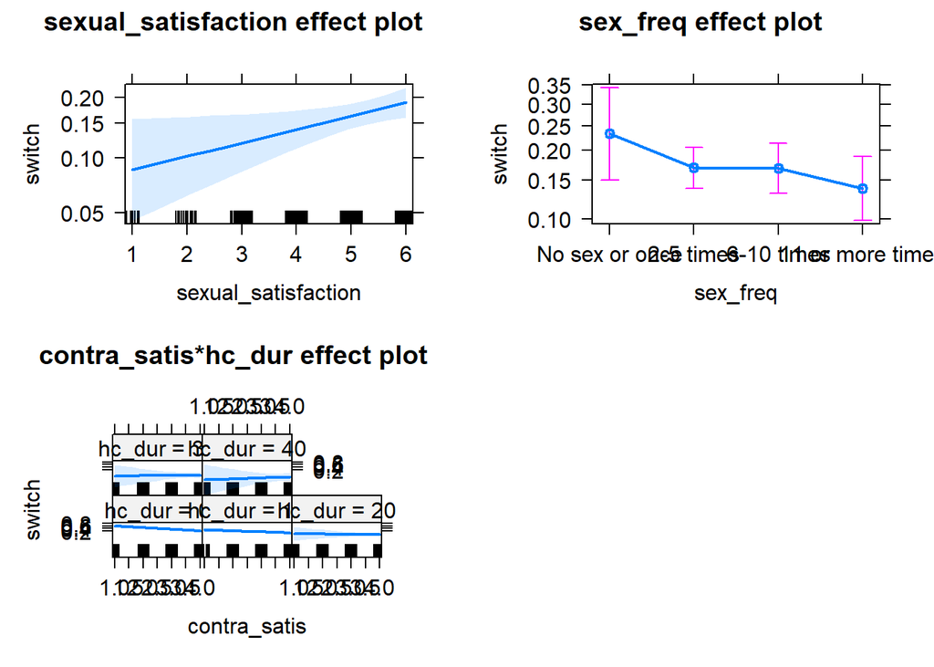

```r
plot(allEffects(R1_sa_m3_lm))
```

```r
#model 4 as linear model (did not converge otherwise)

R1_sa_m4_lm <- glm(switch ~ contra_satis*hc_dur +  sexual_satisfaction +   sex_freq + AGE + DEGREE_recode + POVRATE + HLTHPROB_recode + MEDPROB_recode + GAPINS_recode +
              TYPEINS_recode + NKIDS_t1 +  pregnant_between_waves + had_baby_between_waves+ Avoid_r + FEELPG_recode +
              rel_dur_factor,
            family = binomial,
            data = cccu_R1_SA_sens)

summary(R1_sa_m4_lm)
```

```
##
## Call:
## glm(formula = switch ~ contra_satis * hc_dur + sexual_satisfaction +
##     sex_freq + AGE + DEGREE_recode + POVRATE + HLTHPROB_recode +
##     MEDPROB_recode + GAPINS_recode + TYPEINS_recode + NKIDS_t1 +
##     pregnant_between_waves + had_baby_between_waves + Avoid_r +
##     FEELPG_recode + rel_dur_factor, family = binomial, data = cccu_R1_SA_sens)
##
## Deviance Residuals:
##     Min       1Q   Median       3Q      Max
## -1.5755  -0.6232  -0.4602  -0.3150   3.0148
##
## Coefficients:
##                                                   Estimate  Std. Error z value
## (Intercept)                                    -12.5588059 685.3584155  -0.018
## contra_satis                                    -0.6582145   0.1922909  -3.423
## hc_dur                                          -0.2045682   0.1153392  -1.774
## sexual_satisfaction                              0.1833146   0.0852462   2.150
## sex_freq2-5 times                               -0.2906568   0.3193480  -0.910
## sex_freq6-10 times                              -0.2546419   0.3382234  -0.753
## sex_freq11 or more times                        -0.5118611   0.3630271  -1.410
## AGE                                              0.0361067   0.0221249   1.632
## DEGREE_recode7th/8th grade                      13.9733973 685.3584948   0.020
## DEGREE_recode9th grade                          -0.7723328 816.9040879  -0.001
## DEGREE_recode10th grade                         14.9874263 685.3578196   0.022
## DEGREE_recode11th grade                         12.9466315 685.3583040   0.019
## DEGREE_recode12th grade / no diploma            14.0014248 685.3578067   0.020
## DEGREE_recodehigh school diploma or equivalent  13.8556510 685.3574744   0.020
## DEGREE_recodesome college, no degree            14.0203885 685.3574517   0.020
## DEGREE_recodeassociate degree                   13.2406594 685.3575014   0.019
## DEGREE_recodebachelors degree                   13.9288361 685.3574586   0.020
## DEGREE_recodemasters degree                     13.9068285 685.3574961   0.020
## DEGREE_recodeprofessional or doctoral degree    13.9605443 685.3576396   0.020
## POVRATE                                         -0.0002034   0.0004216  -0.482
## HLTHPROB_recodeYes                               0.2361598   0.2213104   1.067
## MEDPROB_recodeYes                               -0.3910545   0.3138868  -1.246
## GAPINS_recodeYes                                 0.0164988   0.4501843   0.037
## TYPEINS_recodeYes                               -0.0643652   0.5158790  -0.125
## NKIDS_t11                                       -0.0415071   0.2470964  -0.168
## NKIDS_t12                                        0.1941459   0.2755490   0.705
```

[output cut: 44 more lines]

```
## rel_dur_factor0q-25q                              0.738377
## rel_dur_factor26q-50q                             0.866653
## rel_dur_factor51q-75q                             0.615334
## rel_dur_factor76q-100q                            0.616900
## contra_satis:hc_dur                               0.263176
## ---
## Signif. codes:  0 '***' 0.001 '**' 0.01 '*' 0.05 '.' 0.1 ' ' 1
##
## (Dispersion parameter for binomial family taken to be 1)
##
##     Null deviance: 1070.59  on 1130  degrees of freedom
## Residual deviance:  932.62  on 1094  degrees of freedom
## AIC: 1006.6
##
## Number of Fisher Scoring iterations: 14
```

```r
confint(R1_sa_m4_lm, method = "Wald", level = .997)
```

[output not shown]

[output cut: 8 more lines]

[output not shown]

[output not shown]

[output cut: 210 more lines]

[output not shown]

```
##                                                         0.2 %        99.8 %
## (Intercept)                                                NA 135.718413991
## contra_satis                                     -1.238649978  -0.087176053
## hc_dur                                           -0.559042833   0.130434837
## sexual_satisfaction                              -0.062442470   0.445421212
## sex_freq2-5 times                                -1.208240082   0.705200663
## sex_freq6-10 times                               -1.234328591   0.790475079
## sex_freq11 or more times                         -1.577598807   0.595124825
## AGE                                              -0.030383169   0.101395450
## DEGREE_recode7th/8th grade                      203.590404908 388.205478092
## DEGREE_recode9th grade                          -12.181586041  11.266672790
## DEGREE_recode10th grade                        -107.211240014            NA
## DEGREE_recode11th grade                         -18.438915494 362.261413488
## DEGREE_recode12th grade / no diploma           -108.255787077            NA
## DEGREE_recodehigh school diploma or equivalent -140.064776079            NA
## DEGREE_recodesome college, no degree           -140.043776266            NA
## DEGREE_recodeassociate degree                  -140.460705359            NA
## DEGREE_recodebachelors degree                  -140.096921702            NA
## DEGREE_recodemasters degree                    -139.900697530            NA
## DEGREE_recodeprofessional or doctoral degree   -138.435659061            NA
## POVRATE                                          -0.001487832   0.001024886
## HLTHPROB_recodeYes                               -0.440014135   0.879643348
## MEDPROB_recodeYes                                -1.395778417   0.488768713
## GAPINS_recodeYes                                 -1.514716471   1.239349261
## TYPEINS_recodeYes                                -1.741474499   1.398381875
## NKIDS_t11                                        -0.792440220   0.679522790
## NKIDS_t12                                        -0.636531702   1.004388910
## NKIDS_t13                                        -2.505435928   0.611597479
## NKIDS_t14 or more                                -1.371106525   2.309033103
## pregnant_between_wavesYes                        -6.076397889   2.500991515
## had_baby_between_wavesYes                        -2.513607087   6.563983373
## Avoid_r                                          -0.571787997  -0.150664440
## FEELPG_recode                                    -0.163817653   0.244104356
## rel_dur_factor0q-25q                             -0.658164268   0.822334535
## rel_dur_factor26q-50q                            -0.724200490   0.807178409
## rel_dur_factor51q-75q                            -0.734115714   1.017680695
## rel_dur_factor76q-100q                           -1.312835780   0.903575806
## contra_satis:hc_dur                              -0.057394265   0.130525523
```

[figure not shown]

```r
plot(allEffects(R1_sa_m4_lm))
```

###R1_SA: Average marginal effects

####sa_m2

```r
#average marginal effect
ame <- marginaleffects(R1_sa_m2)
summary(ame)
```

```
##           Term   Effect Std. Error z value     Pr(>|z|)     2.5 %    97.5 %
## 1 contra_satis -0.05456   0.011350  -4.807 0.0000015311 -0.076808 -0.032316
## 2       hc_dur -0.00588   0.001274  -4.615 0.0000039316 -0.008377 -0.003383
##
## Model type:  glmerMod
## Prediction type:  response
```

####sa_m3

```r
#average marginal effect
ame <- marginaleffects(R1_sa_m3)
summary(ame)
```

```
##                  Term                          Contrast    Effect Std. Error
## 1        contra_satis                             dY/dX -0.058032   0.011384
## 2              hc_dur                             dY/dX -0.005782   0.001270
## 3 sexual_satisfaction                             dY/dX  0.023137   0.008127
## 4            sex_freq        2-5 times - No sex or once -0.014191   0.037131
## 5            sex_freq       6-10 times - No sex or once -0.031379   0.038377
## 6            sex_freq 11 or more times - No sex or once -0.054298   0.039347
##   z value      Pr(>|z|)     2.5 %    97.5 %
## 1 -5.0975 0.00000034419 -0.080345 -0.035719
## 2 -4.5519 0.00000531692 -0.008271 -0.003292
## 3  2.8469     0.0044149  0.007208  0.039066
## 4 -0.3822     0.7023221 -0.086966  0.058584
## 5 -0.8176     0.4135592 -0.106597  0.043839
## 6 -1.3800     0.1675897 -0.131417  0.022820
##
## Model type:  glmerMod
## Prediction type:  response
```

####sa_m4

```r
#average marginal effect
ame <- marginaleffects(R1_sa_m3_lm)
summary(ame)
```

```
##                  Term                          Contrast   Effect Std. Error
## 1        contra_satis                             dY/dX -0.06591    0.01573
## 2              hc_dur                             dY/dX -0.01151    0.00272
## 3 sexual_satisfaction                             dY/dX  0.02553    0.01124
## 4            sex_freq        2-5 times - No sex or once -0.06366    0.05134
## 5            sex_freq       6-10 times - No sex or once -0.06433    0.05339
## 6            sex_freq 11 or more times - No sex or once -0.09599    0.05441
##   z value    Pr(>|z|)     2.5 %    97.5 %
## 1  -4.191 0.000027729 -0.096732 -0.035090
## 2  -4.233 0.000023030 -0.016843 -0.006183
## 3   2.272    0.023088  0.003506  0.047557
## 4  -1.240    0.215019 -0.164288  0.036971
## 5  -1.205    0.228276 -0.168980  0.040320
## 6  -1.764    0.077693 -0.202639  0.010650
##
## Model type:  glm
## Prediction type:  response
```

```r
#average marginal effect
ame <- marginaleffects(R1_sa_m4_lm)
summary(ame)
```

```
##                      Term                                          Contrast
## 1            contra_satis                                             dY/dX
## 2                  hc_dur                                             dY/dX
## 3     sexual_satisfaction                                             dY/dX
## 4                sex_freq                        2-5 times - No sex or once
## 5                sex_freq                       6-10 times - No sex or once
## 6                sex_freq                 11 or more times - No sex or once
## 7                     AGE                                             dY/dX
## 8           DEGREE_recode                     7th/8th grade - 5th/6th grade
## 9           DEGREE_recode                         9th grade - 5th/6th grade
## 10          DEGREE_recode                        10th grade - 5th/6th grade
## 11          DEGREE_recode                        11th grade - 5th/6th grade
## 12          DEGREE_recode           12th grade / no diploma - 5th/6th grade
## 13          DEGREE_recode high school diploma or equivalent - 5th/6th grade
## 14          DEGREE_recode           some college, no degree - 5th/6th grade
```

[output cut: 96 more lines]

#4. R2:Analysis of Robustness 2

##Main Analysis

###4.1 Model 1: basic model

```r
R2_ma_1 <- glmer(switch ~ hc + (1| CASEID), family = binomial, data = cccu_R2, control=glmerControl(optimizer="bobyqa"))

summary(R2_ma_1)
```

```
## Generalized linear mixed model fit by maximum likelihood (Laplace
##   Approximation) [glmerMod]
##  Family: binomial  ( logit )
## Formula: switch ~ hc + (1 | CASEID)
##    Data: cccu_R2
## Control: glmerControl(optimizer = "bobyqa")
##
##      AIC      BIC   logLik deviance df.resid
##   2781.6   2800.3  -1387.8   2775.6     3784
##
## Scaled residuals:
##     Min      1Q  Median      3Q     Max
## -1.0109 -0.2473 -0.2323 -0.1500  3.0920
##
## Random effects:
##  Groups Name        Variance Std.Dev.
##  CASEID (Intercept) 3.267    1.807
## Number of obs: 3787, groups:  CASEID, 1993
##
## Fixed effects:
##             Estimate Std. Error z value             Pr(>|z|)
## (Intercept)  -2.4181     0.2203 -10.975 < 0.0000000000000002 ***
## hcnon_hc     -1.1611     0.1597  -7.272    0.000000000000354 ***
## ---
## Signif. codes:  0 '***' 0.001 '**' 0.01 '*' 0.05 '.' 0.1 ' ' 1
##
## Correlation of Fixed Effects:
##          (Intr)
## hcnon_hc 0.186
```

```r
confint(R2_ma_1, method = "Wald", level = .997)
```

```
##                0.15 %    99.85 %
## .sig01             NA         NA
## (Intercept) -3.072002 -1.7641992
## hcnon_hc    -1.634928 -0.6872599
```

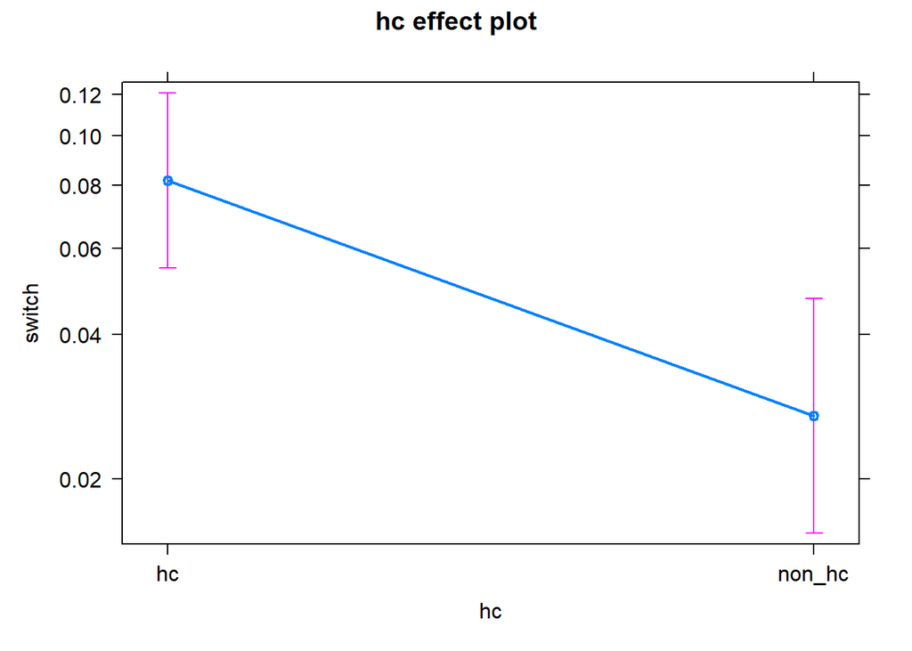

```r
plot(allEffects(R2_ma_1))
```

###4.2 Model 2: including directly with contraceptive method associated predictors

```r
R2_ma_2 <- glmer(switch ~ hc*contra_satis + (1| CASEID), family = binomial, data = cccu_R2, control=glmerControl(optimizer="bobyqa"))

summary(R2_ma_2)
```

```
## Generalized linear mixed model fit by maximum likelihood (Laplace
##   Approximation) [glmerMod]
##  Family: binomial  ( logit )
## Formula: switch ~ hc * contra_satis + (1 | CASEID)
##    Data: cccu_R2
## Control: glmerControl(optimizer = "bobyqa")
##
##      AIC      BIC   logLik deviance df.resid
##   2739.0   2770.2  -1364.5   2729.0     3782
##
## Scaled residuals:
##     Min      1Q  Median      3Q     Max
## -1.5279 -0.2405 -0.2061 -0.1600  3.6568
##
## Random effects:
##  Groups Name        Variance Std.Dev.
##  CASEID (Intercept) 2.823    1.68
## Number of obs: 3787, groups:  CASEID, 1993
##
## Fixed effects:
##                       Estimate Std. Error z value       Pr(>|z|)
## (Intercept)             0.3235     0.4011   0.807        0.41988
## hcnon_hc               -3.1116     0.6485  -4.798 0.000001604817 ***
## contra_satis           -0.7547     0.1174  -6.431 0.000000000127 ***
## hcnon_hc:contra_satis   0.5529     0.1862   2.969        0.00299 **
## ---
## Signif. codes:  0 '***' 0.001 '**' 0.01 '*' 0.05 '.' 0.1 ' ' 1
##
## Correlation of Fixed Effects:
##             (Intr) hcnn_h cntr_s
## hcnon_hc    -0.586
## contra_sats -0.907  0.637
## hcnn_hc:cn_  0.568 -0.971 -0.611
```

```r
confint(R2_ma_2, method = "Wald", level = .997)
```

```
##                              0.15 %    99.85 %
## .sig01                           NA         NA
## (Intercept)           -0.8667873029  1.5138361
## hcnon_hc              -5.0362877796 -1.1868350
## contra_satis          -1.1029828874 -0.4064049
## hcnon_hc:contra_satis  0.0002617458  1.1056243
```

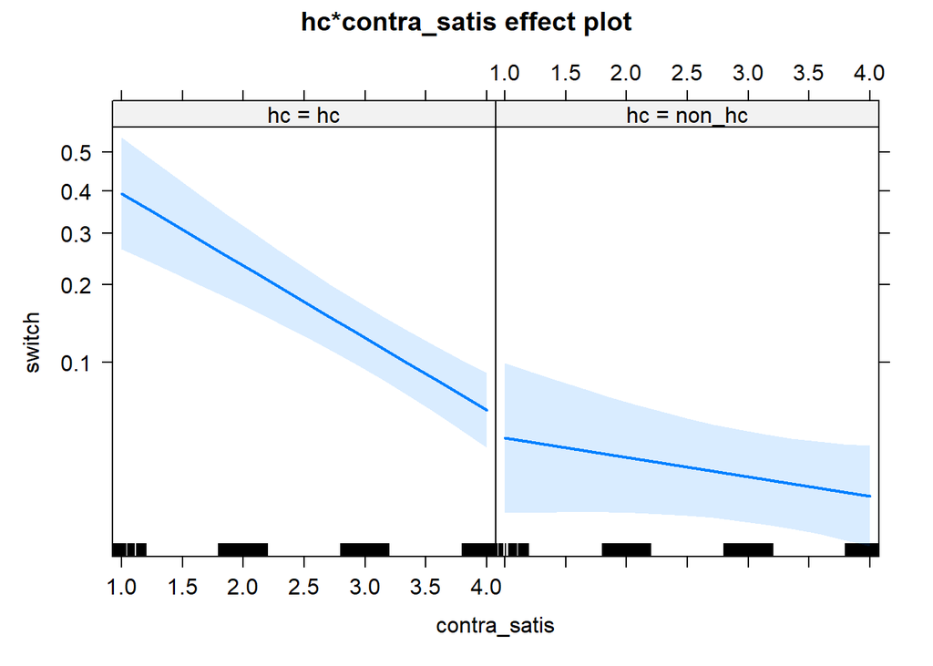

```r
plot(allEffects(R2_ma_2))
```

###4.3 Model 3: including not directly with contraceptive method associated predictors

```r
R2_ma_3 <- glmer(switch ~ hc * contra_satis + hc * sexual_satisfaction + hc * sex_freq + (1| CASEID), family = binomial, data = cccu_R2, control=glmerControl(optimizer="bobyqa"))

summary(R2_ma_3)
```

```
## Generalized linear mixed model fit by maximum likelihood (Laplace
##   Approximation) [glmerMod]
##  Family: binomial  ( logit )
## Formula: switch ~ hc * contra_satis + hc * sexual_satisfaction + hc *
##     sex_freq + (1 | CASEID)
##    Data: cccu_R2
## Control: glmerControl(optimizer = "bobyqa")
##
##      AIC      BIC   logLik deviance df.resid
##   2748.3   2829.4  -1361.1   2722.3     3774
##
## Scaled residuals:
##     Min      1Q  Median      3Q     Max
## -1.5854 -0.2472 -0.2024 -0.1552  4.1485
##
## Random effects:
##  Groups Name        Variance Std.Dev.
##  CASEID (Intercept) 2.801    1.674
## Number of obs: 3787, groups:  CASEID, 1993
##
## Fixed effects:
##                                    Estimate Std. Error z value        Pr(>|z|)
## (Intercept)                       -0.009136   0.513630  -0.018         0.98581
## hcnon_hc                          -2.448041   0.855700  -2.861         0.00422
## contra_satis                      -0.765301   0.118304  -6.469 0.0000000000987
## sexual_satisfaction                0.118000   0.073638   1.602         0.10906
## sex_freq2-5 times                 -0.156165   0.232912  -0.670         0.50255
## sex_freq6-10 times                -0.271310   0.257690  -1.053         0.29241
## sex_freq11 or more times          -0.488976   0.294039  -1.663         0.09632
## hcnon_hc:contra_satis              0.574800   0.190233   3.022         0.00251
## hcnon_hc:sexual_satisfaction      -0.174018   0.128459  -1.355         0.17553
## hcnon_hc:sex_freq2-5 times        -0.024580   0.469206  -0.052         0.95822
## hcnon_hc:sex_freq6-10 times        0.128610   0.515226   0.250         0.80288
## hcnon_hc:sex_freq11 or more times  0.791415   0.565599   1.399         0.16174
##
## (Intercept)
## hcnon_hc                          **
## contra_satis                      ***
## sexual_satisfaction
## sex_freq2-5 times
```

[output cut: 20 more lines]

```
## hcnn_:_2-5t  0.098 -0.319  0.010  0.096 -0.484 -0.336 -0.294 -0.016
## hcn_:_6-10t  0.051 -0.213  0.014  0.134 -0.337 -0.486 -0.293 -0.036
## hcn_:_11omt  0.029 -0.178 -0.009  0.160 -0.309 -0.304 -0.502 -0.020
##             hcnn_hc:s_ h_:_2t h_:_6t
## hcnon_hc
## contra_sats
## sxl_stsfctn
## sx_frq2-5tm
## sx_frq6-10t
## sx_frq11omt
## hcnn_hc:cn_
## hcnn_hc:sx_
## hcnn_:_2-5t -0.154
## hcn_:_6-10t -0.246      0.762
## hcn_:_11omt -0.268      0.695  0.677
```

```r
confint(R2_ma_3, method = "Wald", level = .997)
```

```
##                                        0.15 %     99.85 %
## .sig01                                     NA          NA
## (Intercept)                       -1.53345593  1.51518482
## hcnon_hc                          -4.98753352  0.09145099
## contra_satis                      -1.11639548 -0.41420734
## sexual_satisfaction               -0.10053673  0.33653747
## sex_freq2-5 times                 -0.84738731  0.53505670
## sex_freq6-10 times                -1.03606666  0.49344658
## sex_freq11 or more times          -1.36160820  0.38365523
## hcnon_hc:contra_satis              0.01023826  1.13936267
## hcnon_hc:sexual_satisfaction      -0.55525061  0.20721392
## hcnon_hc:sex_freq2-5 times        -1.41706086  1.36790023
## hcnon_hc:sex_freq6-10 times       -1.40044448  1.65766440
## hcnon_hc:sex_freq11 or more times -0.88713332  2.46996426
```

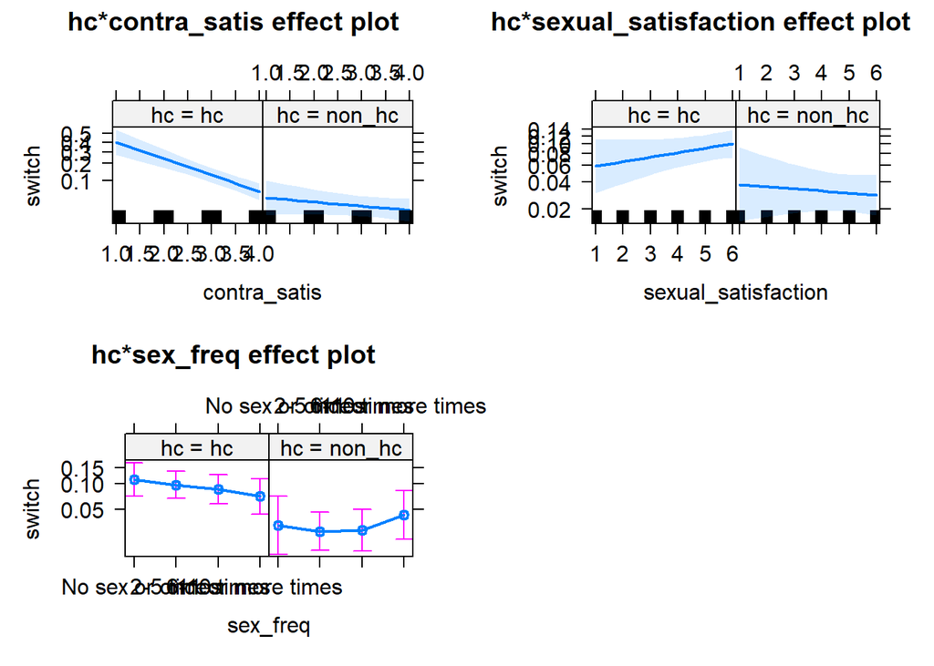

```r
plot(allEffects(R2_ma_3))
```

###4.4 Model 4: Controlling for observed selection effects

```r
#filter for first measurement occasion
length(unique(cccu_R2$CASEID))
```

```
## [1] 1993
```

```r
cccu_R2_sens = cccu_R2 %>%
  group_by(CASEID) %>%
  arrange(WAVE) %>%
  mutate(count = row_number()) %>%
  ungroup()

cccu_R2_sens = cccu_R2_sens %>%
  filter(count == 1)

table(cccu_R2_sens$WAVE)
```

```
##
##   t1   t2   t3   t4
## 1723  201   69    0
```

```r
#repeat model 3 for sensitivity analyses
R2_m3_lm = glm(switch ~ hc * contra_satis + hc * sexual_satisfaction +  hc * sex_freq,
          family = binomial,
          data = cccu_R2_sens)
summary(R2_m3_lm)
```

```
##
## Call:
## glm(formula = switch ~ hc * contra_satis + hc * sexual_satisfaction +
##     hc * sex_freq, family = binomial, data = cccu_R2_sens)
##
## Deviance Residuals:
##     Min       1Q   Median       3Q      Max
## -1.2253  -0.5522  -0.4737  -0.3981   2.3644
##
## Coefficients:
##                                     Estimate Std. Error z value      Pr(>|z|)
## (Intercept)                        0.6672860  0.4751460   1.404       0.16021
## hcnon_hc                          -2.8333714  0.8777340  -3.228       0.00125
## contra_satis                      -0.6213445  0.1053273  -5.899 0.00000000365
## sexual_satisfaction                0.0856086  0.0709763   1.206       0.22776
## sex_freq2-5 times                 -0.4990969  0.2175569  -2.294       0.02178
## sex_freq6-10 times                -0.4476940  0.2397624  -1.867       0.06187
## sex_freq11 or more times          -0.6637965  0.2723131  -2.438       0.01478
## hcnon_hc:contra_satis              0.5012161  0.1901959   2.635       0.00841
## hcnon_hc:sexual_satisfaction       0.0003284  0.1365074   0.002       0.99808
## hcnon_hc:sex_freq2-5 times         0.2074377  0.4556805   0.455       0.64895
## hcnon_hc:sex_freq6-10 times        0.0831579  0.5026310   0.165       0.86859
## hcnon_hc:sex_freq11 or more times  0.5821329  0.5605698   1.038       0.29905
##
## (Intercept)
## hcnon_hc                          **
## contra_satis                      ***
## sexual_satisfaction
## sex_freq2-5 times                 *
## sex_freq6-10 times                .
## sex_freq11 or more times          *
## hcnon_hc:contra_satis             **
## hcnon_hc:sexual_satisfaction
## hcnon_hc:sex_freq2-5 times
## hcnon_hc:sex_freq6-10 times
## hcnon_hc:sex_freq11 or more times
## ---
## Signif. codes:  0 '***' 0.001 '**' 0.01 '*' 0.05 '.' 0.1 ' ' 1
##
## (Dispersion parameter for binomial family taken to be 1)
##
##     Null deviance: 1632.2  on 1992  degrees of freedom
## Residual deviance: 1549.9  on 1981  degrees of freedom
## AIC: 1573.9
##
## Number of Fisher Scoring iterations: 5
```

```r
R2_ma_4 <- glm(switch ~ hc * contra_satis + hc * sexual_satisfaction + hc * sex_freq + hc *AGE + hc *DEGREE_recode + hc *POVRATE + hc *HLTHPROB_recode + hc *MEDPROB_recode +  hc *GAPINS_recode + hc *TYPEINS_recode + hc *NKIDS_t1 +  hc *pregnant_between_waves + hc *had_baby_between_waves+ hc *Avoid_r + hc *FEELPG_recode + hc *rel_dur_factor, family = binomial, data = cccu_R2_sens)

summary(R2_ma_4)
```

```
##
## Call:
## glm(formula = switch ~ hc * contra_satis + hc * sexual_satisfaction +
##     hc * sex_freq + hc * AGE + hc * DEGREE_recode + hc * POVRATE +
##     hc * HLTHPROB_recode + hc * MEDPROB_recode + hc * GAPINS_recode +
##     hc * TYPEINS_recode + hc * NKIDS_t1 + hc * pregnant_between_waves +
##     hc * had_baby_between_waves + hc * Avoid_r + hc * FEELPG_recode +
##     hc * rel_dur_factor, family = binomial, data = cccu_R2_sens)
##
## Deviance Residuals:
##     Min       1Q   Median       3Q      Max
## -2.0597  -0.5627  -0.3956  -0.2163   3.3393
##
## Coefficients: (1 not defined because of singularities)
##                                                             Estimate
## (Intercept)                                              -10.7113947
## hcnon_hc                                                  -2.0360582
## contra_satis                                              -0.5906671
## sexual_satisfaction                                        0.0740298
## sex_freq2-5 times                                         -0.5543285
## sex_freq6-10 times                                        -0.4117843
## sex_freq11 or more times                                  -0.7894012
## AGE                                                        0.0166049
## DEGREE_recode5th/6th grade                                12.2264124
## DEGREE_recode7th/8th grade                                12.4976589
## DEGREE_recode9th grade                                    -2.8398801
## DEGREE_recode10th grade                                   13.7034155
## DEGREE_recode11th grade                                   12.0629286
## DEGREE_recode12th grade / no diploma                      13.2979663
## DEGREE_recodehigh school diploma or equivalent            12.8559992
## DEGREE_recodesome college, no degree                      12.8888702
## DEGREE_recodeassociate degree                             12.1490440
## DEGREE_recodebachelors degree                             12.7471158
## DEGREE_recodemasters degree                               12.8631447
## DEGREE_recodeprofessional or doctoral degree              13.0261282
## POVRATE                                                   -0.0004501
## HLTHPROB_recodeYes                                         0.0960338
## MEDPROB_recodeYes                                         -0.1758847
## GAPINS_recodeYes                                          -0.2977775
## TYPEINS_recodeYes                                         -0.5341830
```

[output cut: 188 more lines]

```
## hcnon_hc:FEELPG_recode                                      0.005715 **
## hcnon_hc:rel_dur_factor0q-25q                               0.294834
## hcnon_hc:rel_dur_factor26q-50q                              0.065011 .
## hcnon_hc:rel_dur_factor51q-75q                              0.531304
## hcnon_hc:rel_dur_factor76q-100q                             0.612698
## ---
## Signif. codes:  0 '***' 0.001 '**' 0.01 '*' 0.05 '.' 0.1 ' ' 1
##
## (Dispersion parameter for binomial family taken to be 1)
##
##     Null deviance: 1632.2  on 1992  degrees of freedom
## Residual deviance: 1376.9  on 1922  degrees of freedom
## AIC: 1518.9
##
## Number of Fisher Scoring iterations: 15
```

```r
confint(R2_ma_4, parm = c("(Intercept)",
                                               "hcnon_hc",
                                               "contra_satis",
                                               "sexual_satisfaction",
                                               "sex_freq2-5 times", "sex_freq6-10 times",
                                               "sex_freq11 or more times",
                                               "hcnon_hc:contra_satis",
                                               "hcnon_hc:sexual_satisfaction",
                                               "hcnon_hc:sex_freq2-5 times",
                                               "hcnon_hc:sex_freq6-10 times",
                                               "hcnon_hc:sex_freq11 or more times"), method = "Wald", level = .997)
```

[output not shown]

[output not shown]

```
##                                        0.2 %       99.8 %
## (Intercept)                               NA 827.84665797
## hcnon_hc                          -8.5457421   4.35531811
## contra_satis                      -0.9346315  -0.24820333
## sexual_satisfaction               -0.1465422   0.30393788
## sex_freq2-5 times                 -1.2561839  -0.14852032
## sex_freq6-10 times                -1.1844754   0.14942134
## sex_freq11 or more times          -1.7021787   0.09913291
## hcnon_hc:contra_satis             -0.2821732   0.78287927
## hcnon_hc:sexual_satisfaction      -0.3370250   0.56102538
## hcnon_hc:sex_freq2-5 times        -0.9198285   2.06654347
## hcnon_hc:sex_freq6-10 times       -1.2535329   2.09197356
## hcnon_hc:sex_freq11 or more times -1.0016627   2.69738024
```

```
## Note:
##   1 value in the hc*DEGREE_recode effect are not estimable
```

[figure not shown]

```r
plot(allEffects(R2_ma_4))
```

###R2: Average marginal effects ####m1

```r
#average marginal effect
ame <- marginaleffects(R2_ma_1)
summary(ame)
```

```
##   Term    Contrast  Effect Std. Error z value         Pr(>|z|)    2.5 %
## 1   hc non_hc - hc -0.0759    0.01174  -6.466 0.00000000010063 -0.09891
##     97.5 %
## 1 -0.05289
##
## Model type:  glmerMod
## Prediction type:  response
```

####m2

```r
#average marginal effect
ame <- marginaleffects(R2_ma_2)
summary(ame)
```

```
##           Term    Contrast   Effect Std. Error z value             Pr(>|z|)
## 1           hc non_hc - hc -0.08805   0.011210  -7.855 0.000000000000003997
## 2 contra_satis       dY/dX -0.04624   0.007264  -6.366 0.000000000193872383
##      2.5 %   97.5 %
## 1 -0.11003 -0.06608
## 2 -0.06048 -0.03201
##
## Model type:  glmerMod
## Prediction type:  response
```

```r
R2_m2_hc_only <- glmer(switch ~ contra_satis + (1| CASEID),
                    family = binomial,
                    data = cccu_R2%>% filter(hc == "hc"),
                    control=glmerControl(optimizer="bobyqa"))
ame <- marginaleffects(R2_m2_hc_only)
summary(ame)
```

```
##           Term   Effect Std. Error z value           Pr(>|z|)    2.5 %   97.5 %
## 1 contra_satis -0.07379     0.0106  -6.964 0.0000000000033036 -0.09455 -0.05302
##
## Model type:  glmerMod
## Prediction type:  response
```

```r
R2_m2_nonhc_only <- glmer(switch ~ contra_satis + (1| CASEID),
                    family = binomial,
                    data = cccu_R2 %>% filter(hc == "non_hc"),
                    control=glmerControl(optimizer="bobyqa"))
ame <- marginaleffects(R2_m2_nonhc_only)
summary(ame)
```

```
##           Term   Effect Std. Error z value Pr(>|z|)    2.5 %   97.5 %
## 1 contra_satis -0.00113   0.005538 -0.2041  0.83825 -0.01198 0.009723
##
## Model type:  glmerMod
## Prediction type:  response
```

####m3

```r
#average marginal effect
ame <- marginaleffects(R2_ma_3)
summary(ame)
```

```
##                  Term                          Contrast    Effect Std. Error
## 1                  hc                       non_hc - hc -0.087475   0.011293
## 2        contra_satis                             dY/dX -0.046608   0.007330
## 3 sexual_satisfaction                             dY/dX  0.005733   0.004623
## 4            sex_freq        2-5 times - No sex or once -0.012631   0.016365
## 5            sex_freq       6-10 times - No sex or once -0.018575   0.017718
## 6            sex_freq 11 or more times - No sex or once -0.021238   0.019449
##   z value              Pr(>|z|)     2.5 %   97.5 %
## 1 -7.7456 0.0000000000000095122 -0.109610 -0.06534
## 2 -6.3584 0.0000000002038870828 -0.060975 -0.03224
## 3  1.2401               0.21494 -0.003328  0.01479
## 4 -0.7718               0.44021 -0.044706  0.01944
## 5 -1.0483               0.29449 -0.053302  0.01615
## 6 -1.0920               0.27484 -0.059357  0.01688
##
## Model type:  glmerMod
## Prediction type:  response
```

```r
R2_m3_hc_only <- glmer(switch ~ contra_satis + sexual_satisfaction + sex_freq +
                      (1| CASEID),
                    family = binomial,
                    data = cccu_R2 %>% filter(hc == "hc"),
                    control=glmerControl(optimizer="bobyqa"))
ame <- marginaleffects(R2_m3_hc_only)
summary(ame)
```

```
##                  Term                          Contrast   Effect Std. Error
## 1        contra_satis                             dY/dX -0.07482   0.010652
## 2 sexual_satisfaction                             dY/dX  0.01105   0.006958
## 3            sex_freq        2-5 times - No sex or once -0.01247   0.024169
## 4            sex_freq       6-10 times - No sex or once -0.02799   0.025829
## 5            sex_freq 11 or more times - No sex or once -0.04479   0.027455
##   z value           Pr(>|z|)     2.5 %   97.5 %
## 1 -7.0239 0.0000000000021581 -0.095699 -0.05394
## 2  1.5881            0.11225 -0.002587  0.02469
## 3 -0.5159            0.60595 -0.059839  0.03490
## 4 -1.0836            0.27853 -0.078614  0.02264
## 5 -1.6314            0.10280 -0.098603  0.00902
##
## Model type:  glmerMod
## Prediction type:  response
```

```r
R2_m3_nonhc_only <- glmer(switch ~ contra_satis + sexual_satisfaction + sex_freq +
                      (1| CASEID),
                    family = binomial,
                    data = cccu_R2 %>% filter(hc == "non_hc"),
                    control=glmerControl(optimizer="bobyqa"))
ame <- marginaleffects(R2_m3_nonhc_only)
summary(ame)
```

```
##                  Term                          Contrast     Effect Std. Error
## 1        contra_satis                             dY/dX -0.0005487   0.005604
## 2 sexual_satisfaction                             dY/dX -0.0022447   0.003912
## 3            sex_freq        2-5 times - No sex or once -0.0155491   0.012347
## 4            sex_freq       6-10 times - No sex or once -0.0137693   0.014194
## 5            sex_freq 11 or more times - No sex or once  0.0004432   0.012111
##    z value Pr(>|z|)     2.5 %   97.5 %
## 1 -0.09790  0.92201 -0.011533 0.010435
## 2 -0.57378  0.56612 -0.009912 0.005423
## 3 -1.25932  0.20791 -0.039749 0.008651
## 4 -0.97009  0.33200 -0.041589 0.014050
## 5  0.03659  0.97081 -0.023295 0.024181
##
## Model type:  glmerMod
## Prediction type:  response
```

####m4

```r
#average marginal effect
ame <- marginaleffects(R2_m3_lm)
summary(ame)
```

```
##                  Term                          Contrast    Effect Std. Error
## 1                  hc                       non_hc - hc -0.109403   0.015568
## 2        contra_satis                             dY/dX -0.056032   0.009972
## 3 sexual_satisfaction                             dY/dX  0.009976   0.007058
## 4            sex_freq        2-5 times - No sex or once -0.056942   0.026321
## 5            sex_freq       6-10 times - No sex or once -0.054948   0.028351
## 6            sex_freq 11 or more times - No sex or once -0.062362   0.030842
##   z value           Pr(>|z|)     2.5 %     97.5 %
## 1  -7.027 0.0000000000021043 -0.139916 -0.0788903
## 2  -5.619 0.0000000192105576 -0.075577 -0.0364874
## 3   1.413           0.157560 -0.003858  0.0238100
## 4  -2.163           0.030513 -0.108529 -0.0053539
## 5  -1.938           0.052611 -0.110515  0.0006198
## 6  -2.022           0.043180 -0.122812 -0.0019122
##
## Model type:  glm
## Prediction type:  response
```

```r
ame <- marginaleffects(R2_ma_4)
summary(ame)
```

```
##                      Term                                             Contrast
## 1                      hc                                          non_hc - hc
## 2            contra_satis                                                dY/dX
## 3     sexual_satisfaction                                                dY/dX
## 4                sex_freq                           2-5 times - No sex or once
## 5                sex_freq                          6-10 times - No sex or once
## 6                sex_freq                    11 or more times - No sex or once
## 7                     AGE                                                dY/dX
## 8           DEGREE_recode                     5th/6th grade - 1st to 4th grade
## 9           DEGREE_recode                     7th/8th grade - 1st to 4th grade
## 10          DEGREE_recode                         9th grade - 1st to 4th grade
## 11          DEGREE_recode                        10th grade - 1st to 4th grade
## 12          DEGREE_recode                        11th grade - 1st to 4th grade
## 13          DEGREE_recode           12th grade / no diploma - 1st to 4th grade
## 14          DEGREE_recode high school diploma or equivalent - 1st to 4th grade
```

[output cut: 99 more lines]

```r
R2_m4_hc_only <- glm(switch ~ contra_satis + sexual_satisfaction +  sex_freq +
                    AGE + DEGREE_recode + POVRATE +
                    HLTHPROB_recode + MEDPROB_recode +  GAPINS_recode +
                    TYPEINS_recode + NKIDS_t1 +  pregnant_between_waves +
                    had_baby_between_waves + Avoid_r + FEELPG_recode +
                    rel_dur_factor,
            family = binomial,
            data = cccu_R2_sens %>% filter(hc == "hc"))

ame <- marginaleffects(R2_m4_hc_only)
summary(ame)
```

```
##                      Term                                          Contrast
## 1            contra_satis                                             dY/dX
## 2     sexual_satisfaction                                             dY/dX
## 3                sex_freq                        2-5 times - No sex or once
## 4                sex_freq                       6-10 times - No sex or once
## 5                sex_freq                 11 or more times - No sex or once
## 6                     AGE                                             dY/dX
## 7           DEGREE_recode                     7th/8th grade - 5th/6th grade
## 8           DEGREE_recode                         9th grade - 5th/6th grade
## 9           DEGREE_recode                        10th grade - 5th/6th grade
## 10          DEGREE_recode                        11th grade - 5th/6th grade
## 11          DEGREE_recode           12th grade / no diploma - 5th/6th grade
## 12          DEGREE_recode high school diploma or equivalent - 5th/6th grade
## 13          DEGREE_recode           some college, no degree - 5th/6th grade
## 14          DEGREE_recode                  associate degree - 5th/6th grade
```

[output cut: 58 more lines]

```r
R2_m4_nonhc_only <- glm(switch ~ contra_satis + sexual_satisfaction +  sex_freq +
                    AGE + DEGREE_recode + POVRATE +
                    HLTHPROB_recode + MEDPROB_recode +  GAPINS_recode +
                    TYPEINS_recode + NKIDS_t1 +  pregnant_between_waves +
                    had_baby_between_waves + Avoid_r + FEELPG_recode +
                    rel_dur_factor,
            family = binomial,
            data = cccu_R2_sens %>% filter(hc == "non_hc"))

ame <- marginaleffects(R2_m4_nonhc_only)
summary(ame)
```

```
##                      Term                                             Contrast
## 1            contra_satis                                                dY/dX
## 2     sexual_satisfaction                                                dY/dX
## 3                sex_freq                           2-5 times - No sex or once
## 4                sex_freq                          6-10 times - No sex or once
## 5                sex_freq                    11 or more times - No sex or once
## 6                     AGE                                                dY/dX
## 7           DEGREE_recode                     5th/6th grade - 1st to 4th grade
## 8           DEGREE_recode                     7th/8th grade - 1st to 4th grade
## 9           DEGREE_recode                         9th grade - 1st to 4th grade
## 10          DEGREE_recode                        10th grade - 1st to 4th grade
## 11          DEGREE_recode                        11th grade - 1st to 4th grade
## 12          DEGREE_recode           12th grade / no diploma - 1st to 4th grade
## 13          DEGREE_recode high school diploma or equivalent - 1st to 4th grade
## 14          DEGREE_recode           some college, no degree - 1st to 4th grade
```

[output cut: 60 more lines]

## R2: Sub Analysis

###3.2 Model 2: including directly with contraceptive method associated predictors

DURATION and satisfaction!

```r
R2_sa_m2 <- glmer(switch ~ contra_satis * hc_dur + (1| CASEID), family = binomial, data = cccu_R2_s, control=glmerControl(optimizer="bobyqa"))
```

```
## boundary (singular) fit: see help('isSingular')
```

```r
summary(R2_sa_m2)
```

```
## Generalized linear mixed model fit by maximum likelihood (Laplace
##   Approximation) [glmerMod]
##  Family: binomial  ( logit )
## Formula: switch ~ contra_satis * hc_dur + (1 | CASEID)
##    Data: cccu_R2_s
## Control: glmerControl(optimizer = "bobyqa")
##
##      AIC      BIC   logLik deviance df.resid
##   1936.4   1965.1   -963.2   1926.4     2279
##
## Scaled residuals:
##     Min      1Q  Median      3Q     Max
## -1.3320 -0.4414 -0.3871 -0.3283  4.5769
##
## Random effects:
##  Groups Name        Variance Std.Dev.
##  CASEID (Intercept) 0        0
## Number of obs: 2284, groups:  CASEID, 1226
##
## Fixed effects:
##                     Estimate Std. Error z value    Pr(>|z|)
## (Intercept)          1.27267    0.46236   2.753     0.00591 **
## contra_satis        -0.69929    0.13380  -5.226 0.000000173 ***
## hc_dur              -0.12741    0.04874  -2.614     0.00894 **
## contra_satis:hc_dur  0.02260    0.01359   1.663     0.09621 .
## ---
## Signif. codes:  0 '***' 0.001 '**' 0.01 '*' 0.05 '.' 0.1 ' ' 1
##
## Correlation of Fixed Effects:
##             (Intr) cntr_s hc_dur
## contra_sats -0.973
## hc_dur      -0.794  0.762
## cntr_sts:h_  0.792 -0.798 -0.981
## optimizer (bobyqa) convergence code: 0 (OK)
## boundary (singular) fit: see help('isSingular')
```

```r
confint(R2_sa_m2, method = "Wald", level = .997)
```

```
##                          0.15 %     99.85 %
## .sig01                       NA          NA
## (Intercept)         -0.09948101  2.64482730
## contra_satis        -1.09636481 -0.30221154
## hc_dur              -0.27205443  0.01722792
## contra_satis:hc_dur -0.01771919  0.06291882
```

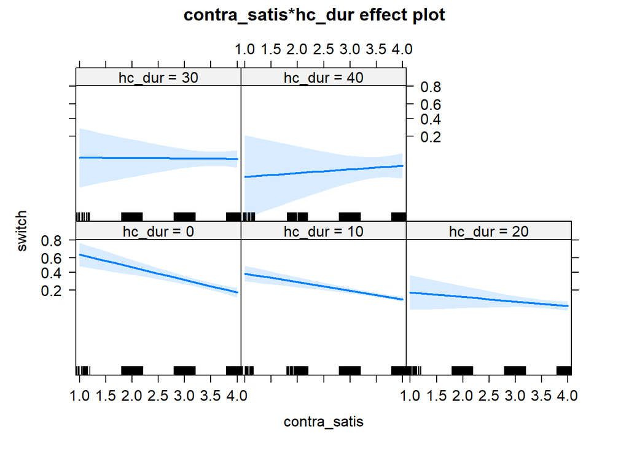

```r
plot(allEffects(R2_sa_m2))
```

###3.3 Model 3: including directly with contraceptive method associated predictors

DURATION and satisfaction!

```r
R2_sa_m3 <- glmer(switch ~ contra_satis * hc_dur +   sexual_satisfaction +  sex_freq + (1| CASEID), family = binomial, data = cccu_R2_s, control=glmerControl(optimizer="bobyqa"))
```

```
## boundary (singular) fit: see help('isSingular')
```

```r
summary(R2_sa_m3)
```

```
## Generalized linear mixed model fit by maximum likelihood (Laplace
##   Approximation) [glmerMod]
##  Family: binomial  ( logit )
## Formula: switch ~ contra_satis * hc_dur + sexual_satisfaction + sex_freq +
##     (1 | CASEID)
##    Data: cccu_R2_s
## Control: glmerControl(optimizer = "bobyqa")
##
##      AIC      BIC   logLik deviance df.resid
##   1938.7   1990.3   -960.4   1920.7     2275
##
## Scaled residuals:
##     Min      1Q  Median      3Q     Max
## -1.4669 -0.4405 -0.3790 -0.3199  4.5294
##
## Random effects:
##  Groups Name        Variance Std.Dev.
##  CASEID (Intercept) 0        0
## Number of obs: 2284, groups:  CASEID, 1226
##
## Fixed effects:
##                          Estimate Std. Error z value   Pr(>|z|)
## (Intercept)               0.95599    0.51816   1.845     0.0650 .
## contra_satis             -0.71028    0.13457  -5.278 0.00000013 ***
## hc_dur                   -0.12511    0.04877  -2.565     0.0103 *
## sexual_satisfaction       0.10394    0.05451   1.907     0.0566 .
## sex_freq2-5 times        -0.12103    0.17140  -0.706     0.4801
## sex_freq6-10 times       -0.21471    0.19073  -1.126     0.2603
## sex_freq11 or more times -0.39939    0.21602  -1.849     0.0645 .
## contra_satis:hc_dur       0.02209    0.01357   1.627     0.1037
## ---
## Signif. codes:  0 '***' 0.001 '**' 0.01 '*' 0.05 '.' 0.1 ' ' 1
##
## Correlation of Fixed Effects:
##             (Intr) cntr_s hc_dur sxl_st s_2-5t s_6-1t s_1omt
## contra_sats -0.830
## hc_dur      -0.710  0.759
## sxl_stsfctn -0.395 -0.072  0.013
## sx_frq2-5tm -0.120 -0.018 -0.018 -0.197
## sx_frq6-10t -0.027 -0.043 -0.052 -0.285  0.669
## sx_frq11omt -0.031 -0.002 -0.011 -0.323  0.604  0.578
## cntr_sts:h_  0.706 -0.795 -0.981 -0.008  0.019  0.044  0.012
## optimizer (bobyqa) convergence code: 0 (OK)
## boundary (singular) fit: see help('isSingular')
```

```r
confint(R2_sa_m3, method = "Wald", level = .997)
```

```
##                               0.15 %     99.85 %
## .sig01                            NA          NA
## (Intercept)              -0.58178026  2.49376633
## contra_satis             -1.10964557 -0.31091841
## hc_dur                   -0.26984191  0.01963111
## sexual_satisfaction      -0.05784371  0.26572781
## sex_freq2-5 times        -0.62969559  0.38764268
## sex_freq6-10 times       -0.78075347  0.35133593
## sex_freq11 or more times -1.04047079  0.24168649
## contra_satis:hc_dur      -0.01819766  0.06236781
```

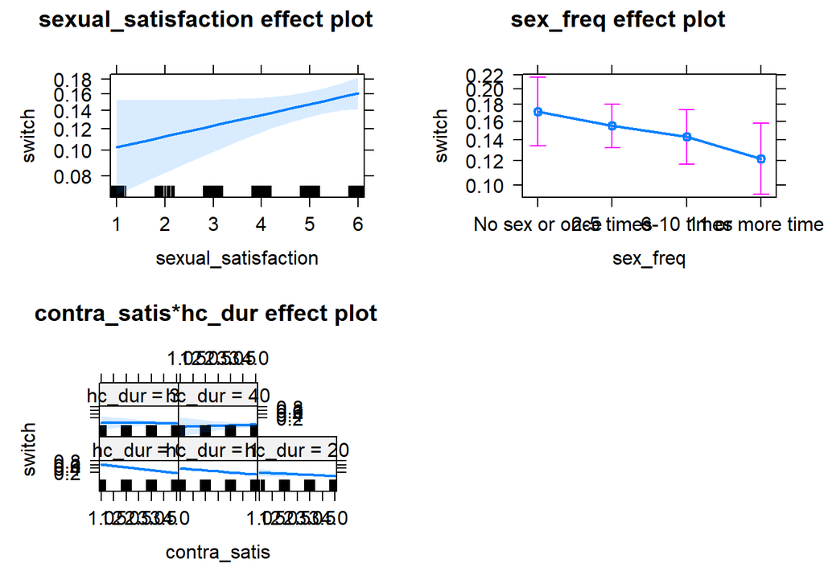

```r
plot(allEffects(R2_sa_m3))
```

###3.3 Model 4: including directly with contraceptive method associated predictors

DURATION and satisfaction!

```r
#filter for first measurement occasion
length(unique(cccu_R2_s$CASEID))
```

```
## [1] 1226
```

```r
cccu_R2_SA_sens = cccu_R2_s %>%
  group_by(CASEID) %>%
  arrange(WAVE) %>%
  mutate(count = row_number()) %>%
  ungroup()

cccu_R2_SA_sens = cccu_R2_SA_sens %>%
  filter(count == 1)

table(cccu_R2_SA_sens$WAVE)
```

```
##
##   t1   t2   t3   t4
## 1032  135   59    0
```

```r
#repeating model 3 as linear model
R2_sa_m3_lm <- glm(switch ~ contra_satis* hc_dur  +  sexual_satisfaction +  sex_freq, family = binomial, data = cccu_R2_SA_sens)

summary(R2_sa_m3_lm)
```

```
##
## Call:
## glm(formula = switch ~ contra_satis * hc_dur + sexual_satisfaction +
##     sex_freq, family = binomial, data = cccu_R2_SA_sens)
##
## Deviance Residuals:
##     Min       1Q   Median       3Q      Max
## -1.6626  -0.6608  -0.5521  -0.4382   2.7958
##
## Coefficients:
##                          Estimate Std. Error z value  Pr(>|z|)
## (Intercept)               1.17708    0.64989   1.811    0.0701 .
## contra_satis             -0.67207    0.16880  -3.982 0.0000685 ***
## hc_dur                   -0.16593    0.10207  -1.626    0.1040
## sexual_satisfaction       0.12148    0.06841   1.776    0.0758 .
## sex_freq2-5 times        -0.46821    0.21279  -2.200    0.0278 *
## sex_freq6-10 times       -0.42825    0.23561  -1.818    0.0691 .
## sex_freq11 or more times -0.65051    0.26445  -2.460    0.0139 *
## contra_satis:hc_dur       0.02500    0.02818   0.887    0.3750
## ---
## Signif. codes:  0 '***' 0.001 '**' 0.01 '*' 0.05 '.' 0.1 ' ' 1
##
## (Dispersion parameter for binomial family taken to be 1)
##
##     Null deviance: 1195.3  on 1225  degrees of freedom
## Residual deviance: 1126.5  on 1218  degrees of freedom
## AIC: 1142.5
##
## Number of Fisher Scoring iterations: 4
```

```r
confint(R2_sa_m3_lm, method = "Wald", level = .997)
```

```
##                                0.2 %     99.8 %
## (Intercept)              -0.74345654  3.1375732
## contra_satis             -1.18486474 -0.1759228
## hc_dur                   -0.48037382  0.1297577
## sexual_satisfaction      -0.07691590  0.3303963
## sex_freq2-5 times        -1.09448752  0.1734865
## sex_freq6-10 times       -1.12783773  0.2762344
## sex_freq11 or more times -1.44619195  0.1309183
## contra_satis:hc_dur      -0.05788075  0.1105397
```

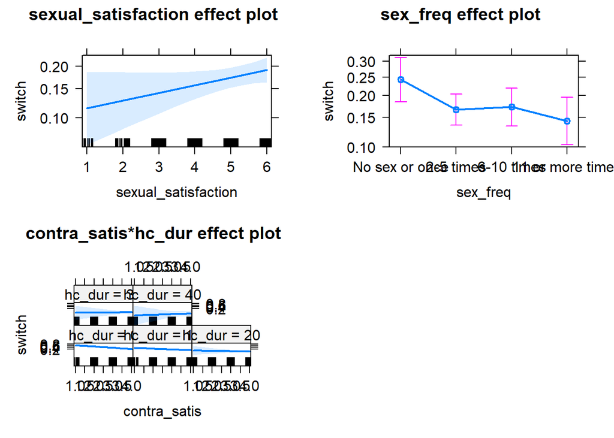

```r
plot(allEffects(R2_sa_m3_lm))
```

```r
#model 4 as linear model (did not converge otherwise)

R2_sa_m4_lm <- glm(switch ~ contra_satis*hc_dur +  sexual_satisfaction +   sex_freq + AGE + DEGREE_recode + POVRATE + HLTHPROB_recode + MEDPROB_recode + GAPINS_recode +
              TYPEINS_recode + NKIDS_t1 +  pregnant_between_waves + had_baby_between_waves+ Avoid_r + FEELPG_recode +
              rel_dur_factor,
            family = binomial,
            data = cccu_R2_SA_sens)

summary(R2_sa_m4_lm)
```

```
##
## Call:
## glm(formula = switch ~ contra_satis * hc_dur + sexual_satisfaction +
##     sex_freq + AGE + DEGREE_recode + POVRATE + HLTHPROB_recode +
##     MEDPROB_recode + GAPINS_recode + TYPEINS_recode + NKIDS_t1 +
##     pregnant_between_waves + had_baby_between_waves + Avoid_r +
##     FEELPG_recode + rel_dur_factor, family = binomial, data = cccu_R2_SA_sens)
##
## Deviance Residuals:
##     Min       1Q   Median       3Q      Max
## -1.6764  -0.6425  -0.4723  -0.3156   3.0710
##
## Coefficients:
##                                                   Estimate  Std. Error z value
## (Intercept)                                      1.9391963   1.6170376   1.199
## contra_satis                                    -0.7282402   0.1790735  -4.067
## hc_dur                                          -0.2021649   0.1092619  -1.850
## sexual_satisfaction                              0.1349978   0.0735308   1.836
## sex_freq2-5 times                               -0.5006039   0.2302147  -2.175
## sex_freq6-10 times                              -0.4177540   0.2537456  -1.646
## sex_freq11 or more times                        -0.7358936   0.2900984  -2.537
## AGE                                              0.0206285   0.0210569   0.980
## DEGREE_recode7th/8th grade                       0.4824523   1.7026770   0.283
## DEGREE_recode9th grade                         -14.2604322 454.6517932  -0.031
## DEGREE_recode10th grade                          1.3394420   1.4230521   0.941
## DEGREE_recode11th grade                         -0.6642055   1.6364936  -0.406
## DEGREE_recode12th grade / no diploma             0.6542490   1.3865161   0.472
## DEGREE_recodehigh school diploma or equivalent   0.3881380   1.2338567   0.315
## DEGREE_recodesome college, no degree             0.4516728   1.2259155   0.368
## DEGREE_recodeassociate degree                   -0.2803433   1.2482201  -0.225
## DEGREE_recodebachelors degree                    0.3194279   1.2239296   0.261
## DEGREE_recodemasters degree                      0.3536238   1.2389597   0.285
## DEGREE_recodeprofessional or doctoral degree     0.4366632   1.3111201   0.333
## POVRATE                                         -0.0004147   0.0003940  -1.053
## HLTHPROB_recodeYes                               0.1588418   0.2064918   0.769
## MEDPROB_recodeYes                               -0.2213310   0.2771733  -0.799
## GAPINS_recodeYes                                -0.0522334   0.4056608  -0.129
## TYPEINS_recodeYes                               -0.0616307   0.4659470  -0.132
## NKIDS_t11                                       -0.0496493   0.2292086  -0.217
## NKIDS_t12                                        0.1901063   0.2617430   0.726
```

[output cut: 44 more lines]

```
## rel_dur_factor0q-25q                                 0.1836
## rel_dur_factor26q-50q                                0.3840
## rel_dur_factor51q-75q                                0.1793
## rel_dur_factor76q-100q                               0.9793
## contra_satis:hc_dur                                  0.2291
## ---
## Signif. codes:  0 '***' 0.001 '**' 0.01 '*' 0.05 '.' 0.1 ' ' 1
##
## (Dispersion parameter for binomial family taken to be 1)
##
##     Null deviance: 1195.3  on 1225  degrees of freedom
## Residual deviance: 1037.6  on 1189  degrees of freedom
## AIC: 1111.6
##
## Number of Fisher Scoring iterations: 14
```

```r
confint(R2_sa_m4_lm, method = "Wald", level = .997)
```

[output not shown]

[output cut: 26 more lines]

[output not shown]

[output not shown]

[output cut: 164 more lines]

[output not shown]

```
##                                                         0.2 %          99.8 %
## (Intercept)                                      -4.251140838    6.4991346440
## contra_satis                                     -1.269975362   -0.1994472766
## hc_dur                                           -0.536852311    0.1157177621
## sexual_satisfaction                              -0.078860858    0.3589427544
## sex_freq2-5 times                                -1.179842508    0.1916971199
## sex_freq6-10 times                               -1.171799880    0.3398864573
## sex_freq11 or more times                         -1.610474930    0.1191667920
## AGE                                              -0.042704395    0.0826548905
## DEGREE_recode7th/8th grade                       -5.762481760    6.7127665828
## DEGREE_recode9th grade                         -262.241031039 -134.6303306161
## DEGREE_recode10th grade                          -2.599056511    7.2459255141
## DEGREE_recode11th grade                          -6.792835697    5.4586638813
## DEGREE_recode12th grade / no diploma             -3.146415382    6.5088498246
## DEGREE_recodehigh school diploma or equivalent   -2.870388993    6.0441546212
## DEGREE_recodesome college, no degree             -2.775747024    6.0993579400
## DEGREE_recodeassociate degree                    -3.591355665    5.3932477302
## DEGREE_recodebachelors degree                    -2.908091742    5.9631813969
## DEGREE_recodemasters degree                      -2.927072745    6.0146829580
## DEGREE_recodeprofessional or doctoral degree     -3.109959378    6.1871029872
## POVRATE                                          -0.001622512    0.0007256602
## HLTHPROB_recodeYes                               -0.470496596    0.7598635309
## MEDPROB_recodeYes                                -1.093377604    0.5653127604
## GAPINS_recodeYes                                 -1.400364340    1.0639946273
## TYPEINS_recodeYes                                -1.548808177    1.2692317411
## NKIDS_t11                                        -0.745336306    0.6194614929
## NKIDS_t12                                        -0.598918169    0.9594352707
## NKIDS_t13                                        -1.752264956    0.9295561503
## NKIDS_t14 or more                                -1.393158927    2.2621239359
## pregnant_between_wavesYes                        -2.514816448    2.6063196596
## had_baby_between_wavesYes                        -3.160860630    2.5658549643
## Avoid_r                                          -0.542539405   -0.1578123533
## FEELPG_recode                                    -0.144591071    0.2292367680
## rel_dur_factor0q-25q                             -0.387609795    1.0150828984
## rel_dur_factor26q-50q                            -0.516394556    0.9416255702
## rel_dur_factor51q-75q                            -0.454400429    1.1926746819
## rel_dur_factor76q-100q                           -1.077964865    1.0297836150
## contra_satis:hc_dur                              -0.052278783    0.1267352179
```

[figure not shown]

```r
plot(allEffects(R2_sa_m4_lm))
```

###R2_SA: Average marginal effects

####sa_m2

```r
#average marginal effect
ame <- marginaleffects(R2_sa_m2)
summary(ame)
```

```
##           Term    Effect Std. Error z value        Pr(>|z|)     2.5 %    97.5 %
## 1 contra_satis -0.062438   0.010553  -5.916 0.0000000032903 -0.083122 -0.041754
## 2       hc_dur -0.006383   0.001206  -5.291 0.0000001216931 -0.008747 -0.004018
##
## Model type:  glmerMod
## Prediction type:  response
```

####sa_m3

```r
#average marginal effect
ame <- marginaleffects(R2_sa_m3)
summary(ame)
```

```
##                  Term                          Contrast    Effect Std. Error
## 1        contra_satis                             dY/dX -0.064281   0.010630
## 2              hc_dur                             dY/dX -0.006292   0.001206
## 3 sexual_satisfaction                             dY/dX  0.013350   0.006997
## 4            sex_freq        2-5 times - No sex or once -0.016695   0.024055
## 5            sex_freq       6-10 times - No sex or once -0.028787   0.026026
## 6            sex_freq 11 or more times - No sex or once -0.050567   0.027526
##   z value        Pr(>|z|)      2.5 %    97.5 %
## 1  -6.047 0.0000000014762 -0.0851155 -0.043446
## 2  -5.218 0.0000001806635 -0.0086557 -0.003929
## 3   1.908        0.056395 -0.0003638  0.027064
## 4  -0.694        0.487655 -0.0638431  0.030452
## 5  -1.106        0.268687 -0.0797970  0.022223
## 6  -1.837        0.066201 -0.1045172  0.003383
##
## Model type:  glmerMod
## Prediction type:  response
```

####sa_m4

```r
#average marginal effect
ame <- marginaleffects(R2_sa_m3_lm)
summary(ame)
```

```
##                  Term                          Contrast   Effect Std. Error
## 1        contra_satis                             dY/dX -0.07591   0.014888
## 2              hc_dur                             dY/dX -0.01169   0.002663
## 3 sexual_satisfaction                             dY/dX  0.01760   0.009883
## 4            sex_freq        2-5 times - No sex or once -0.07502   0.035805
## 5            sex_freq       6-10 times - No sex or once -0.06933   0.039011
## 6            sex_freq 11 or more times - No sex or once -0.09937   0.040555
##   z value      Pr(>|z|)     2.5 %    97.5 %
## 1  -5.099 0.00000034201 -0.105087 -0.046728
## 2  -4.391 0.00001126527 -0.016914 -0.006475
## 3   1.780      0.075002 -0.001774  0.036967
## 4  -2.095      0.036142 -0.145200 -0.004847
## 5  -1.777      0.075551 -0.145786  0.007133
## 6  -2.450      0.014277 -0.178853 -0.019882
##
## Model type:  glm
## Prediction type:  response
```

```r
#average marginal effect
ame <- marginaleffects(R2_sa_m4_lm)
summary(ame)
```

```
##                      Term                                          Contrast
## 1            contra_satis                                             dY/dX
## 2                  hc_dur                                             dY/dX
## 3     sexual_satisfaction                                             dY/dX
## 4                sex_freq                        2-5 times - No sex or once
## 5                sex_freq                       6-10 times - No sex or once
## 6                sex_freq                 11 or more times - No sex or once
## 7                     AGE                                             dY/dX
## 8           DEGREE_recode                     7th/8th grade - 5th/6th grade
## 9           DEGREE_recode                         9th grade - 5th/6th grade
## 10          DEGREE_recode                        10th grade - 5th/6th grade
## 11          DEGREE_recode                        11th grade - 5th/6th grade
## 12          DEGREE_recode           12th grade / no diploma - 5th/6th grade
## 13          DEGREE_recode high school diploma or equivalent - 5th/6th grade
## 14          DEGREE_recode           some college, no degree - 5th/6th grade
```

[output cut: 60 more lines]

#5. Analysis of Robustness R3

##Main Analysis

###5.1 Model 1: basic model

```r
R3_ma_1 <- glmer(switch ~ hc + (1| CASEID), family = binomial, data = cccu_R3, control=glmerControl(optimizer="bobyqa"))

summary(R3_ma_1)
```

```
## Generalized linear mixed model fit by maximum likelihood (Laplace
##   Approximation) [glmerMod]
##  Family: binomial  ( logit )
## Formula: switch ~ hc + (1 | CASEID)
##    Data: cccu_R3
## Control: glmerControl(optimizer = "bobyqa")
##
##      AIC      BIC   logLik deviance df.resid
##   2765.2   2783.9  -1379.6   2759.2     3747
##
## Scaled residuals:
##     Min      1Q  Median      3Q     Max
## -1.0265 -0.2422 -0.2273 -0.1475  3.0585
##
## Random effects:
##  Groups Name        Variance Std.Dev.
##  CASEID (Intercept) 3.457    1.859
## Number of obs: 3750, groups:  CASEID, 1984
##
## Fixed effects:
##             Estimate Std. Error z value             Pr(>|z|)
## (Intercept)  -2.4528     0.2490  -9.850 < 0.0000000000000002 ***
## hcnon_hc     -1.1548     0.1642  -7.034     0.00000000000201 ***
## ---
## Signif. codes:  0 '***' 0.001 '**' 0.01 '*' 0.05 '.' 0.1 ' ' 1
##
## Correlation of Fixed Effects:
##          (Intr)
## hcnon_hc 0.236
```

```r
confint(R3_ma_1, method = "Wald", level = .997)
```

```
##                0.15 %    99.85 %
## .sig01             NA         NA
## (Intercept) -3.191772 -1.7137796
## hcnon_hc    -1.642123 -0.6675722
```

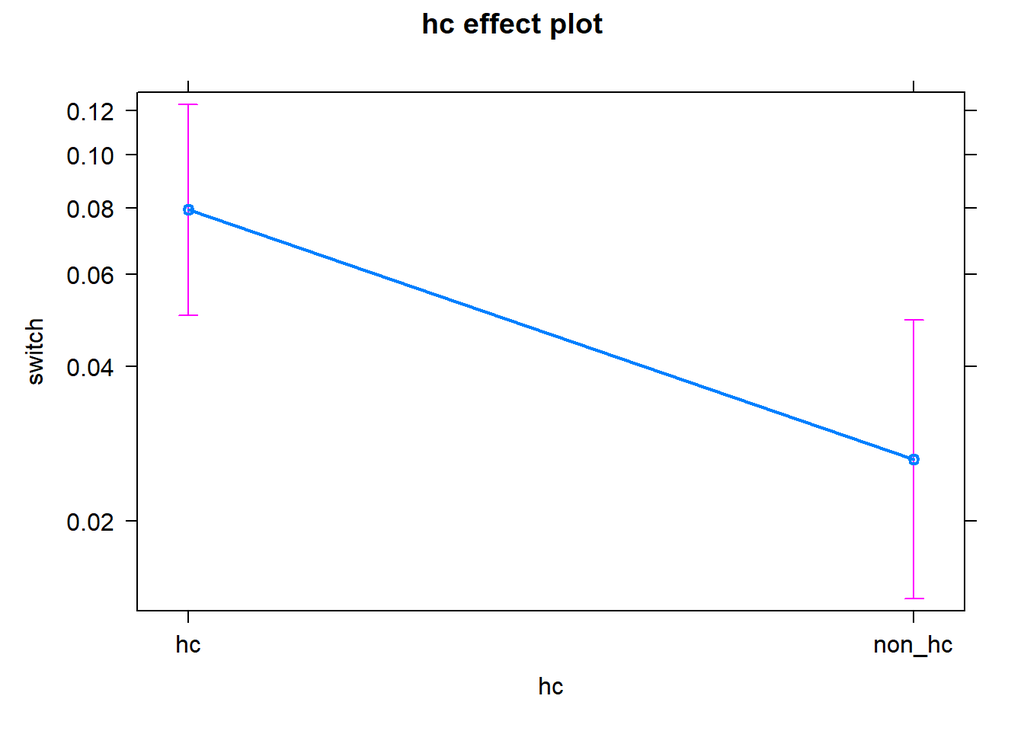

```r
plot(allEffects(R3_ma_1))
```

###5.2 Model 2: including directly with contraceptive method associated predictors

```r
R3_ma_2 <- glmer(switch ~ hc*contra_satis + (1| CASEID), family = binomial, data = cccu_R3, control=glmerControl(optimizer="bobyqa"))

summary(R3_ma_2)
```

```
## Generalized linear mixed model fit by maximum likelihood (Laplace
##   Approximation) [glmerMod]
##  Family: binomial  ( logit )
## Formula: switch ~ hc * contra_satis + (1 | CASEID)
##    Data: cccu_R3
## Control: glmerControl(optimizer = "bobyqa")
##
##      AIC      BIC   logLik deviance df.resid
##   2723.9   2755.0  -1356.9   2713.9     3745
##
## Scaled residuals:
##     Min      1Q  Median      3Q     Max
## -1.5297 -0.2394 -0.2049 -0.1600  3.6268
##
## Random effects:
##  Groups Name        Variance Std.Dev.
##  CASEID (Intercept) 2.88     1.697
## Number of obs: 3750, groups:  CASEID, 1984
##
## Fixed effects:
##                       Estimate Std. Error z value       Pr(>|z|)
## (Intercept)             0.2952     0.4042   0.730        0.46515
## hcnon_hc               -3.0823     0.6538  -4.714 0.000002426640 ***
## contra_satis           -0.7495     0.1179  -6.355 0.000000000208 ***
## hcnon_hc:contra_satis   0.5481     0.1880   2.915        0.00356 **
## ---
## Signif. codes:  0 '***' 0.001 '**' 0.01 '*' 0.05 '.' 0.1 ' ' 1
##
## Correlation of Fixed Effects:
##             (Intr) hcnn_h cntr_s
## hcnon_hc    -0.581
## contra_sats -0.902  0.635
## hcnn_hc:cn_  0.563 -0.970 -0.608
```

```r
confint(R3_ma_2, method = "Wald", level = .997)
```

```
##                           0.15 %    99.85 %
## .sig01                        NA         NA
## (Intercept)           -0.9043872  1.4948648
## hcnon_hc              -5.0227103 -1.1418951
## contra_satis          -1.0995020 -0.3995103
## hcnon_hc:contra_satis -0.0099911  1.1061634
```

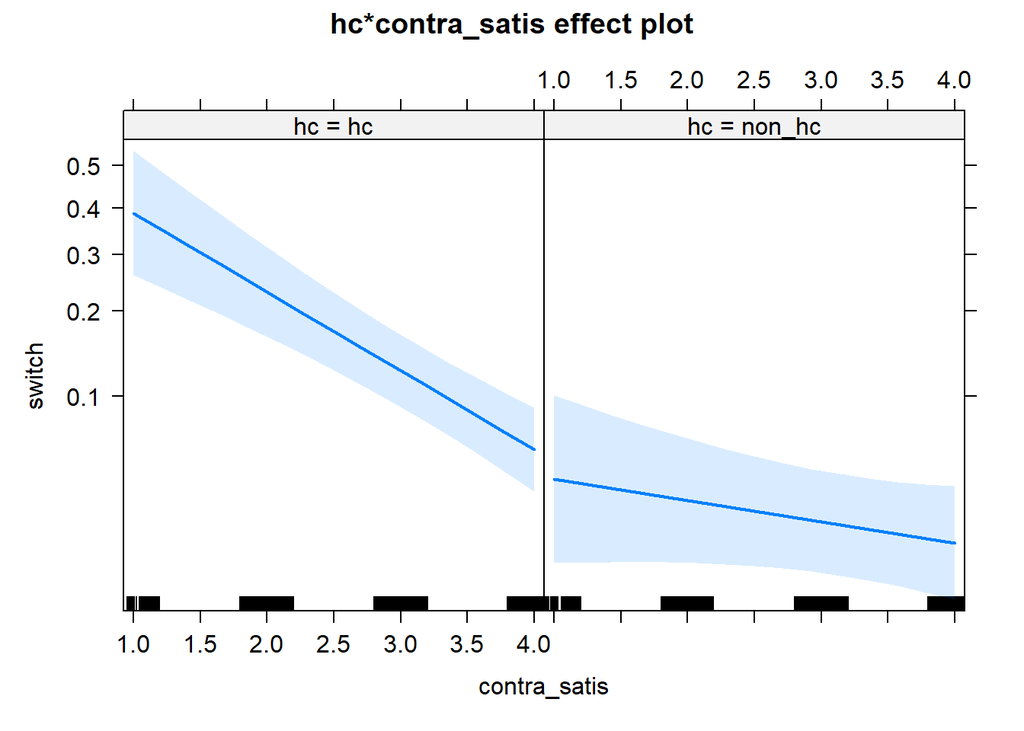

```r
plot(allEffects(R3_ma_2))
```

###5.3 Model 3: including not directly with contraceptive method associated predictors

```r
R3_ma_3 <- glmer(switch ~ hc * contra_satis + hc * sexual_satisfaction + hc * sex_freq + (1| CASEID), family = binomial, data = cccu_R3, control=glmerControl(optimizer="bobyqa"))

summary(R3_ma_3)
```

```
## Generalized linear mixed model fit by maximum likelihood (Laplace
##   Approximation) [glmerMod]
##  Family: binomial  ( logit )
## Formula: switch ~ hc * contra_satis + hc * sexual_satisfaction + hc *
##     sex_freq + (1 | CASEID)
##    Data: cccu_R3
## Control: glmerControl(optimizer = "bobyqa")
##
##      AIC      BIC   logLik deviance df.resid
##   2733.3   2814.3  -1353.7   2707.3     3737
##
## Scaled residuals:
##     Min      1Q  Median      3Q     Max
## -1.5682 -0.2465 -0.2026 -0.1557  4.1299
##
## Random effects:
##  Groups Name        Variance Std.Dev.
##  CASEID (Intercept) 2.844    1.686
## Number of obs: 3750, groups:  CASEID, 1984
##
## Fixed effects:
##                                    Estimate Std. Error z value       Pr(>|z|)
## (Intercept)                       -0.006681   0.515708  -0.013        0.98966
## hcnon_hc                          -2.444493   0.860854  -2.840        0.00452
## contra_satis                      -0.758663   0.118599  -6.397 0.000000000159
## sexual_satisfaction                0.109283   0.073949   1.478        0.13946
## sex_freq2-5 times                 -0.150202   0.233882  -0.642        0.52074
## sex_freq6-10 times                -0.252093   0.258680  -0.975        0.32979
## sex_freq11 or more times          -0.470606   0.295195  -1.594        0.11089
## hcnon_hc:contra_satis              0.565043   0.191832   2.946        0.00322
## hcnon_hc:sexual_satisfaction      -0.162568   0.129057  -1.260        0.20779
## hcnon_hc:sex_freq2-5 times        -0.051869   0.472429  -0.110        0.91257
## hcnon_hc:sex_freq6-10 times        0.120376   0.518469   0.232        0.81640
## hcnon_hc:sex_freq11 or more times  0.800458   0.569193   1.406        0.15963
##
## (Intercept)
## hcnon_hc                          **
## contra_satis                      ***
## sexual_satisfaction
## sex_freq2-5 times
```

[output cut: 20 more lines]

```
## hcnn_:_2-5t  0.099 -0.318  0.011  0.096 -0.484 -0.336 -0.294 -0.017
## hcn_:_6-10t  0.052 -0.210  0.016  0.132 -0.337 -0.485 -0.292 -0.041
## hcn_:_11omt  0.030 -0.177 -0.008  0.160 -0.309 -0.304 -0.502 -0.024
##             hcnn_hc:s_ h_:_2t h_:_6t
## hcnon_hc
## contra_sats
## sxl_stsfctn
## sx_frq2-5tm
## sx_frq6-10t
## sx_frq11omt
## hcnn_hc:cn_
## hcnn_hc:sx_
## hcnn_:_2-5t -0.154
## hcn_:_6-10t -0.246      0.762
## hcn_:_11omt -0.265      0.694  0.677
```

```r
confint(R3_ma_3, method = "Wald", level = .997)
```

```
##                                         0.15 %    99.85 %
## .sig01                                      NA         NA
## (Intercept)                       -1.537167744  1.5238059
## hcnon_hc                          -4.999281346  0.1102963
## contra_satis                      -1.110632137 -0.4066935
## sexual_satisfaction               -0.110177683  0.3287442
## sex_freq2-5 times                 -0.844301275  0.5438977
## sex_freq6-10 times                -1.019787587  0.5156011
## sex_freq11 or more times          -1.346668349  0.4054567
## hcnon_hc:contra_satis             -0.004262624  1.1343492
## hcnon_hc:sexual_satisfaction      -0.545574500  0.2204376
## hcnon_hc:sex_freq2-5 times        -1.453913395  1.3501747
## hcnon_hc:sex_freq6-10 times       -1.418304288  1.6590562
## hcnon_hc:sex_freq11 or more times -0.888756828  2.4896728
```

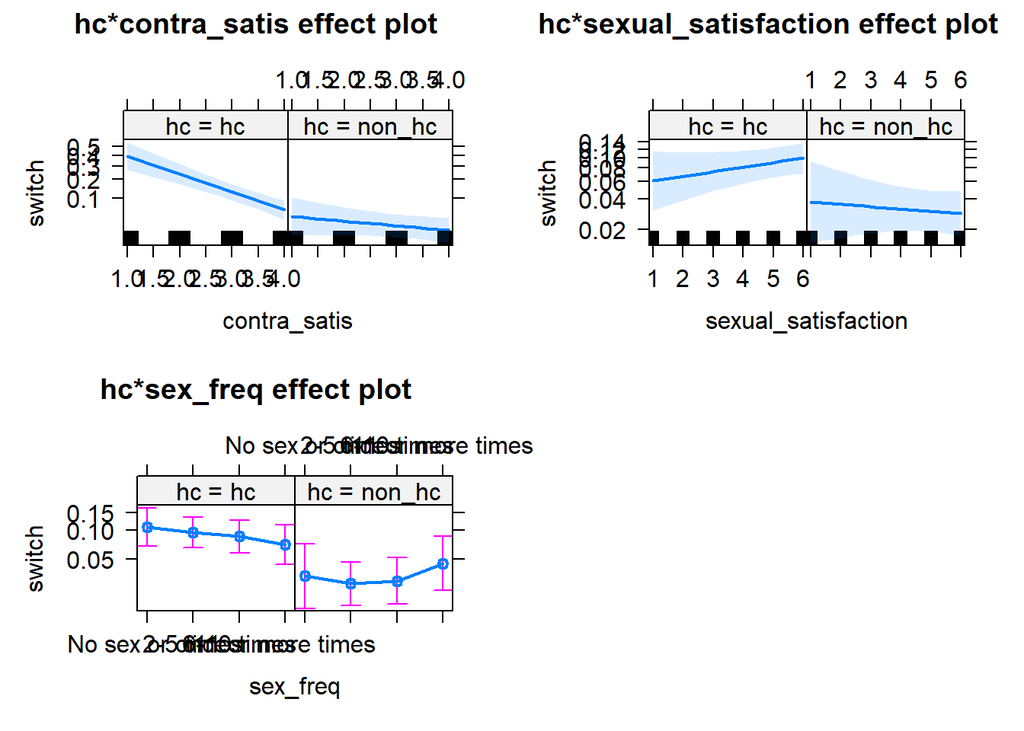

```r
plot(allEffects(R3_ma_3))
```

###5.4 Model 4: Controlling for observed selection effects

```r
#filter for first measurement occasion
length(unique(cccu_R3$CASEID))
```

```
## [1] 1984
```

```r
cccu_R3_sens = cccu_R3 %>%
  group_by(CASEID) %>%
  arrange(WAVE) %>%
  mutate(count = row_number()) %>%
  ungroup()

cccu_R3_sens = cccu_R3_sens %>%
  filter(count == 1)

table(cccu_R3_sens$WAVE)
```

```
##
##   t1   t2   t3   t4
## 1723  194   67    0
```

```r
#repeat model 3 for sensitivity analyses
R3_m3_lm = glm(switch ~ hc * contra_satis + hc * sexual_satisfaction +  hc * sex_freq,
          family = binomial,
          data = cccu_R3_sens)
summary(R3_m3_lm)
```

```
##
## Call:
## glm(formula = switch ~ hc * contra_satis + hc * sexual_satisfaction +
##     hc * sex_freq, family = binomial, data = cccu_R3_sens)
##
## Deviance Residuals:
##     Min       1Q   Median       3Q      Max
## -1.2243  -0.5591  -0.4812  -0.4000   2.3564
##
## Coefficients:
##                                    Estimate Std. Error z value      Pr(>|z|)
## (Intercept)                        0.666442   0.475073   1.403       0.16067
## hcnon_hc                          -2.828803   0.878331  -3.221       0.00128
## contra_satis                      -0.620527   0.105333  -5.891 0.00000000384
## sexual_satisfaction                0.085165   0.070967   1.200       0.23012
## sex_freq2-5 times                 -0.498833   0.217547  -2.293       0.02185
## sex_freq6-10 times                -0.447336   0.239753  -1.866       0.06207
## sex_freq11 or more times          -0.659125   0.272431  -2.419       0.01555
## hcnon_hc:contra_satis              0.502068   0.190702   2.633       0.00847
## hcnon_hc:sexual_satisfaction      -0.001164   0.136212  -0.009       0.99318
## hcnon_hc:sex_freq2-5 times         0.220516   0.455684   0.484       0.62844
## hcnon_hc:sex_freq6-10 times        0.093787   0.502910   0.186       0.85206
## hcnon_hc:sex_freq11 or more times  0.588923   0.560564   1.051       0.29345
##
## (Intercept)
## hcnon_hc                          **
## contra_satis                      ***
## sexual_satisfaction
## sex_freq2-5 times                 *
## sex_freq6-10 times                .
## sex_freq11 or more times          *
## hcnon_hc:contra_satis             **
## hcnon_hc:sexual_satisfaction
## hcnon_hc:sex_freq2-5 times
## hcnon_hc:sex_freq6-10 times
## hcnon_hc:sex_freq11 or more times
## ---
## Signif. codes:  0 '***' 0.001 '**' 0.01 '*' 0.05 '.' 0.1 ' ' 1
##
## (Dispersion parameter for binomial family taken to be 1)
##
##     Null deviance: 1629.4  on 1983  degrees of freedom
## Residual deviance: 1548.3  on 1972  degrees of freedom
## AIC: 1572.3
##
## Number of Fisher Scoring iterations: 5
```

```r
confint(R3_m3_lm, method = "Wald", level = .997)
```

```
##                                         0.2 %     99.8 %
## (Intercept)                       -0.76570062  2.0647776
## hcnon_hc                          -5.56341138 -0.3194203
## contra_satis                      -0.93502798 -0.3067727
## sexual_satisfaction               -0.12081482  0.3017410
## sex_freq2-5 times                 -1.13914050  0.1575913
## sex_freq6-10 times                -1.15932647  0.2698889
## sex_freq11 or more times          -1.48015773  0.1454706
## hcnon_hc:contra_satis             -0.05238314  1.0844999
## hcnon_hc:sexual_satisfaction      -0.39267735  0.4207936
## hcnon_hc:sex_freq2-5 times        -1.07392492  1.6796439
## hcnon_hc:sex_freq6-10 times       -1.36670830  1.6669324
## hcnon_hc:sex_freq11 or more times -1.07970729  2.3030949
```

```r
R3_ma_4 <- glm(switch ~ hc * contra_satis + hc * sexual_satisfaction + hc * sex_freq + hc *AGE + hc *DEGREE_recode + hc *POVRATE + hc *HLTHPROB_recode + hc *MEDPROB_recode +  hc *GAPINS_recode + hc *TYPEINS_recode + hc *NKIDS_t1 +  hc *pregnant_between_waves + hc *had_baby_between_waves+ hc *Avoid_r + hc *FEELPG_recode + hc *rel_dur_factor, family = binomial, data = cccu_R3_sens)

summary(R3_ma_4)
```

```
##
## Call:
## glm(formula = switch ~ hc * contra_satis + hc * sexual_satisfaction +
##     hc * sex_freq + hc * AGE + hc * DEGREE_recode + hc * POVRATE +
##     hc * HLTHPROB_recode + hc * MEDPROB_recode + hc * GAPINS_recode +
##     hc * TYPEINS_recode + hc * NKIDS_t1 + hc * pregnant_between_waves +
##     hc * had_baby_between_waves + hc * Avoid_r + hc * FEELPG_recode +
##     hc * rel_dur_factor, family = binomial, data = cccu_R3_sens)
##
## Deviance Residuals:
##     Min       1Q   Median       3Q      Max
## -2.0581  -0.5636  -0.3964  -0.2174   3.3364
##
## Coefficients: (1 not defined because of singularities)
##                                                             Estimate
## (Intercept)                                              -10.7803043
## hcnon_hc                                                  -1.9993708
## contra_satis                                              -0.5898927
## sexual_satisfaction                                        0.0735053
## sex_freq2-5 times                                         -0.5532816
## sex_freq6-10 times                                        -0.4109186
## sex_freq11 or more times                                  -0.7836137
## AGE                                                        0.0166868
## DEGREE_recode5th/6th grade                                12.2923029
## DEGREE_recode7th/8th grade                                12.5655829
## DEGREE_recode9th grade                                    -2.7741262
## DEGREE_recode10th grade                                   13.7713459
## DEGREE_recode11th grade                                   12.1310165
## DEGREE_recode12th grade / no diploma                      13.3643344
## DEGREE_recodehigh school diploma or equivalent            12.9229260
## DEGREE_recodesome college, no degree                      12.9556602
## DEGREE_recodeassociate degree                             12.2163941
## DEGREE_recodebachelors degree                             12.8160371
## DEGREE_recodemasters degree                               12.9303147
## DEGREE_recodeprofessional or doctoral degree              13.0932429
## POVRATE                                                   -0.0004504
## HLTHPROB_recodeYes                                         0.0949408
## MEDPROB_recodeYes                                         -0.1759484
## GAPINS_recodeYes                                          -0.2986749
## TYPEINS_recodeYes                                         -0.5345612
```

[output cut: 188 more lines]

```
## hcnon_hc:FEELPG_recode                                      0.005398 **
## hcnon_hc:rel_dur_factor0q-25q                               0.287310
## hcnon_hc:rel_dur_factor26q-50q                              0.061959 .
## hcnon_hc:rel_dur_factor51q-75q                              0.519119
## hcnon_hc:rel_dur_factor76q-100q                             0.625708
## ---
## Signif. codes:  0 '***' 0.001 '**' 0.01 '*' 0.05 '.' 0.1 ' ' 1
##
## (Dispersion parameter for binomial family taken to be 1)
##
##     Null deviance: 1629.4  on 1983  degrees of freedom
## Residual deviance: 1376.1  on 1913  degrees of freedom
## AIC: 1518.1
##
## Number of Fisher Scoring iterations: 15
```

```r
confint(R3_ma_4, parm = c("(Intercept)",
                                               "hcnon_hc",
                                               "contra_satis",
                                               "sexual_satisfaction",
                                               "sex_freq2-5 times", "sex_freq6-10 times",
                                               "sex_freq11 or more times",
                                               "hcnon_hc:contra_satis",
                                               "hcnon_hc:sexual_satisfaction",
                                               "hcnon_hc:sex_freq2-5 times",
                                               "hcnon_hc:sex_freq6-10 times",
                                               "hcnon_hc:sex_freq11 or more times"), method = "Wald", level= .997)
```

[output not shown]

[output cut: 82 more lines]

[output not shown]

```
##                                        0.2 %      99.8 %
## (Intercept)                               NA 827.8335459
## hcnon_hc                          -8.4865104   4.3761674
## contra_satis                      -0.9338538  -0.2474253
## sexual_satisfaction               -0.1470616   0.3034033
## sex_freq2-5 times                 -1.2552100   0.1618064
## sex_freq6-10 times                -1.1835531   0.3659951
## sex_freq11 or more times          -1.6971175   0.1057431
## hcnon_hc:contra_satis             -0.2793050   0.9579335
## hcnon_hc:sexual_satisfaction      -0.3372138   0.5594172
## hcnon_hc:sex_freq2-5 times        -0.9082149   2.0794457
## hcnon_hc:sex_freq6-10 times       -1.2455106   2.0994234
## hcnon_hc:sex_freq11 or more times -0.9950420   2.7059426
```

```
## Note:
##   1 value in the hc*DEGREE_recode effect are not estimable
```

[figure not shown]

```r
plot(allEffects(R3_ma_4))
```

###R3: Average marginal effects ####m1

```r
#average marginal effect
ame <- marginaleffects(R3_ma_1)
summary(ame)
```

```
##   Term    Contrast   Effect Std. Error z value        Pr(>|z|)    2.5 %
## 1   hc non_hc - hc -0.07487    0.01235  -6.063 0.0000000013392 -0.09907
##     97.5 %
## 1 -0.05067
##
## Model type:  glmerMod
## Prediction type:  response
```

####m2

```r
#average marginal effect
ame <- marginaleffects(R3_ma_2)
summary(ame)
```

```
##           Term    Contrast   Effect Std. Error z value             Pr(>|z|)
## 1           hc non_hc - hc -0.08710   0.011333  -7.686 0.000000000000015179
## 2 contra_satis       dY/dX -0.04605   0.007355  -6.261 0.000000000383128198
##      2.5 %   97.5 %
## 1 -0.10931 -0.06489
## 2 -0.06047 -0.03163
##
## Model type:  glmerMod
## Prediction type:  response
```

```r
R3_m2_hc_only <- glmer(switch ~ contra_satis + (1| CASEID),
                    family = binomial,
                    data = cccu_R3%>% filter(hc == "hc"),
                    control=glmerControl(optimizer="bobyqa"))
ame <- marginaleffects(R3_m2_hc_only)
summary(ame)
```

```
##           Term   Effect Std. Error z value           Pr(>|z|)    2.5 %   97.5 %
## 1 contra_satis -0.07347    0.01062   -6.92 0.0000000000045103 -0.09428 -0.05266
##
## Model type:  glmerMod
## Prediction type:  response
```

```r
R3_m2_nonhc_only <- glmer(switch ~ contra_satis + (1| CASEID),
                    family = binomial,
                    data = cccu_R3 %>% filter(hc == "non_hc"),
                    control=glmerControl(optimizer="bobyqa"))
ame <- marginaleffects(R3_m2_nonhc_only)
summary(ame)
```

```
##           Term    Effect Std. Error z value Pr(>|z|)    2.5 %   97.5 %
## 1 contra_satis -0.001177    0.00567 -0.2076  0.83551 -0.01229 0.009935
##
## Model type:  glmerMod
## Prediction type:  response
```

####m3

```r
#average marginal effect
ame <- marginaleffects(R3_ma_3)
summary(ame)
```

```
##                  Term                          Contrast    Effect Std. Error
## 1                  hc                       non_hc - hc -0.086386   0.011405
## 2        contra_satis                             dY/dX -0.046445   0.007419
## 3 sexual_satisfaction                             dY/dX  0.005314   0.004659
## 4            sex_freq        2-5 times - No sex or once -0.012593   0.016419
## 5            sex_freq       6-10 times - No sex or once -0.017299   0.017822
## 6            sex_freq 11 or more times - No sex or once -0.019678   0.019606
##   z value             Pr(>|z|)     2.5 %   97.5 %
## 1 -7.5744 0.000000000000036082 -0.108739 -0.06403
## 2 -6.2599 0.000000000385318215 -0.060986 -0.03190
## 3  1.1406              0.25405 -0.003817  0.01445
## 4 -0.7670              0.44308 -0.044773  0.01959
## 5 -0.9706              0.33174 -0.052230  0.01763
## 6 -1.0037              0.31554 -0.058106  0.01875
##
## Model type:  glmerMod
## Prediction type:  response
```

```r
R3_m3_hc_only <- glmer(switch ~ contra_satis + sexual_satisfaction + sex_freq +
                      (1| CASEID),
                    family = binomial,
                    data = cccu_R3 %>% filter(hc == "hc"),
                    control=glmerControl(optimizer="bobyqa"))
ame <- marginaleffects(R3_m3_hc_only)
summary(ame)
```

```
##                  Term                          Contrast   Effect Std. Error
## 1        contra_satis                             dY/dX -0.07452   0.010678
## 2 sexual_satisfaction                             dY/dX  0.01064   0.006967
## 3            sex_freq        2-5 times - No sex or once -0.01267   0.024138
## 4            sex_freq       6-10 times - No sex or once -0.02681   0.025847
## 5            sex_freq 11 or more times - No sex or once -0.04419   0.027458
##   z value           Pr(>|z|)     2.5 %    97.5 %
## 1 -6.9781 0.0000000000029911 -0.095445 -0.053586
## 2  1.5273            0.12670 -0.003015  0.024296
## 3 -0.5247            0.59980 -0.059975  0.034645
## 4 -1.0373            0.29960 -0.077471  0.023849
## 5 -1.6094            0.10753 -0.098008  0.009626
##
## Model type:  glmerMod
## Prediction type:  response
```

```r
R3_m3_nonhc_only <- glmer(switch ~ contra_satis + sexual_satisfaction + sex_freq +
                      (1| CASEID),
                    family = binomial,
                    data = cccu_R3 %>% filter(hc == "non_hc"),
                    control=glmerControl(optimizer="bobyqa"))
ame <- marginaleffects(R3_m3_nonhc_only)
summary(ame)
```

```
##                  Term                          Contrast     Effect Std. Error
## 1        contra_satis                             dY/dX -0.0005525   0.005740
## 2 sexual_satisfaction                             dY/dX -0.0022950   0.003987
## 3            sex_freq        2-5 times - No sex or once -0.0160660   0.012644
## 4            sex_freq       6-10 times - No sex or once -0.0138898   0.014484
## 5            sex_freq 11 or more times - No sex or once  0.0006498   0.012300
##    z value Pr(>|z|)    2.5 %   97.5 %
## 1 -0.09625  0.92332 -0.01180 0.010698
## 2 -0.57561  0.56488 -0.01011 0.005519
## 3 -1.27066  0.20385 -0.04085 0.008715
## 4 -0.95900  0.33756 -0.04228 0.014498
## 5  0.05283  0.95787 -0.02346 0.024757
##
## Model type:  glmerMod
## Prediction type:  response
```

####m4

```r
ame <- marginaleffects(R3_m3_lm)
summary(ame)
```

```
##                  Term                          Contrast    Effect Std. Error
## 1                  hc                       non_hc - hc -0.108727   0.015629
## 2        contra_satis                             dY/dX -0.056157   0.010025
## 3 sexual_satisfaction                             dY/dX  0.009918   0.007082
## 4            sex_freq        2-5 times - No sex or once -0.056619   0.026351
## 5            sex_freq       6-10 times - No sex or once -0.054684   0.028397
## 6            sex_freq 11 or more times - No sex or once -0.061799   0.030921
##   z value           Pr(>|z|)     2.5 %     97.5 %
## 1  -6.957 0.0000000000034824 -0.139359 -0.0780947
## 2  -5.602 0.0000000212476776 -0.075806 -0.0365074
## 3   1.400           0.161367 -0.003962  0.0237976
## 4  -2.149           0.031662 -0.108266 -0.0049722
## 5  -1.926           0.054143 -0.110340  0.0009732
## 6  -1.999           0.045651 -0.122404 -0.0011948
##
## Model type:  glm
## Prediction type:  response
```

```r
ame <- marginaleffects(R3_ma_4)
summary(ame)
```

```
##                      Term                                             Contrast
## 1                      hc                                          non_hc - hc
## 2            contra_satis                                                dY/dX
## 3     sexual_satisfaction                                                dY/dX
## 4                sex_freq                           2-5 times - No sex or once
## 5                sex_freq                          6-10 times - No sex or once
## 6                sex_freq                    11 or more times - No sex or once
## 7                     AGE                                                dY/dX
## 8           DEGREE_recode                     5th/6th grade - 1st to 4th grade
## 9           DEGREE_recode                     7th/8th grade - 1st to 4th grade
## 10          DEGREE_recode                         9th grade - 1st to 4th grade
## 11          DEGREE_recode                        10th grade - 1st to 4th grade
## 12          DEGREE_recode                        11th grade - 1st to 4th grade
## 13          DEGREE_recode           12th grade / no diploma - 1st to 4th grade
## 14          DEGREE_recode high school diploma or equivalent - 1st to 4th grade
```

[output cut: 99 more lines]

```r
R3_m4_hc_only <- glm(switch ~ contra_satis + sexual_satisfaction +  sex_freq +
                    AGE + DEGREE_recode + POVRATE +
                    HLTHPROB_recode + MEDPROB_recode +  GAPINS_recode +
                    TYPEINS_recode + NKIDS_t1 +  pregnant_between_waves +
                    had_baby_between_waves + Avoid_r + FEELPG_recode +
                    rel_dur_factor,
            family = binomial,
            data = cccu_R3_sens %>% filter(hc == "hc"))

ame <- marginaleffects(R3_m4_hc_only)
summary(ame)
```

```
##                      Term                                          Contrast
## 1            contra_satis                                             dY/dX
## 2     sexual_satisfaction                                             dY/dX
## 3                sex_freq                        2-5 times - No sex or once
## 4                sex_freq                       6-10 times - No sex or once
## 5                sex_freq                 11 or more times - No sex or once
## 6                     AGE                                             dY/dX
## 7           DEGREE_recode                     7th/8th grade - 5th/6th grade
## 8           DEGREE_recode                         9th grade - 5th/6th grade
## 9           DEGREE_recode                        10th grade - 5th/6th grade
## 10          DEGREE_recode                        11th grade - 5th/6th grade
## 11          DEGREE_recode           12th grade / no diploma - 5th/6th grade
## 12          DEGREE_recode high school diploma or equivalent - 5th/6th grade
## 13          DEGREE_recode           some college, no degree - 5th/6th grade
## 14          DEGREE_recode                  associate degree - 5th/6th grade
```

[output cut: 58 more lines]

```r
R3_m4_nonhc_only <- glm(switch ~ contra_satis + sexual_satisfaction +  sex_freq +
                    AGE + DEGREE_recode + POVRATE +
                    HLTHPROB_recode + MEDPROB_recode +  GAPINS_recode +
                    TYPEINS_recode + NKIDS_t1 +  pregnant_between_waves +
                    had_baby_between_waves + Avoid_r + FEELPG_recode +
                    rel_dur_factor,
            family = binomial,
            data = cccu_R3_sens %>% filter(hc == "non_hc"))

ame <- marginaleffects(R3_m4_nonhc_only)
summary(ame)
```

```
##                      Term                                             Contrast
## 1            contra_satis                                                dY/dX
## 2     sexual_satisfaction                                                dY/dX
## 3                sex_freq                           2-5 times - No sex or once
## 4                sex_freq                          6-10 times - No sex or once
## 5                sex_freq                    11 or more times - No sex or once
## 6                     AGE                                                dY/dX
## 7           DEGREE_recode                     5th/6th grade - 1st to 4th grade
## 8           DEGREE_recode                     7th/8th grade - 1st to 4th grade
## 9           DEGREE_recode                         9th grade - 1st to 4th grade
## 10          DEGREE_recode                        10th grade - 1st to 4th grade
## 11          DEGREE_recode                        11th grade - 1st to 4th grade
## 12          DEGREE_recode           12th grade / no diploma - 1st to 4th grade
## 13          DEGREE_recode high school diploma or equivalent - 1st to 4th grade
## 14          DEGREE_recode           some college, no degree - 1st to 4th grade
```

[output cut: 96 more lines]

## Sub Analysis

###3.2 Model 2: including directly with contraceptive method associated predictors

DURATION and satisfaction!

```r
R3_sa_m2 <- glmer(switch ~ contra_satis * hc_dur + (1| CASEID), family = binomial, data = cccu_R3_s, control=glmerControl(optimizer="bobyqa"))
```

```
## boundary (singular) fit: see help('isSingular')
```

```r
summary(R3_sa_m2)
```

```
## Generalized linear mixed model fit by maximum likelihood (Laplace
##   Approximation) [glmerMod]
##  Family: binomial  ( logit )
## Formula: switch ~ contra_satis * hc_dur + (1 | CASEID)
##    Data: cccu_R3_s
## Control: glmerControl(optimizer = "bobyqa")
##
##      AIC      BIC   logLik deviance df.resid
##   1930.5   1959.2   -960.3   1920.5     2273
##
## Scaled residuals:
##     Min      1Q  Median      3Q     Max
## -1.3414 -0.4424 -0.3840 -0.3279  4.6046
##
## Random effects:
##  Groups Name        Variance                         Std.Dev.
##  CASEID (Intercept) 0.000000000000000000000000001928 0.00000000000004391
## Number of obs: 2278, groups:  CASEID, 1224
##
## Fixed effects:
##                     Estimate Std. Error z value    Pr(>|z|)
## (Intercept)          1.28943    0.46394   2.779     0.00545 **
## contra_satis        -0.70205    0.13417  -5.233 0.000000167 ***
## hc_dur              -0.13149    0.04932  -2.666     0.00767 **
## contra_satis:hc_dur  0.02351    0.01373   1.713     0.08672 .
## ---
## Signif. codes:  0 '***' 0.001 '**' 0.01 '*' 0.05 '.' 0.1 ' ' 1
##
## Correlation of Fixed Effects:
##             (Intr) cntr_s hc_dur
## contra_sats -0.973
## hc_dur      -0.794  0.762
## cntr_sts:h_  0.793 -0.798 -0.981
## optimizer (bobyqa) convergence code: 0 (OK)
## boundary (singular) fit: see help('isSingular')
```

```r
confint(R3_sa_m2, method = "Wald", level = .997)
```

```
##                          0.15 %     99.85 %
## .sig01                       NA          NA
## (Intercept)         -0.08741903  2.66628717
## contra_satis        -1.10022339 -0.30387907
## hc_dur              -0.27785271  0.01486582
## contra_satis:hc_dur -0.01722263  0.06424587
```

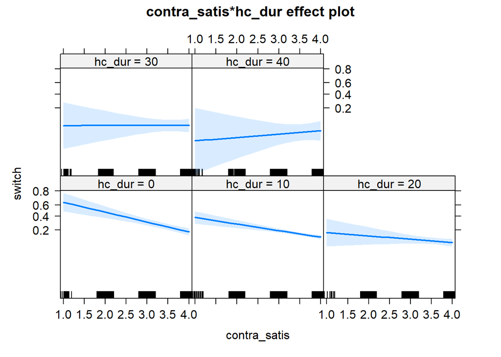

```r
plot(allEffects(R3_sa_m2))
```

###3.3 Model 3: including directly with contraceptive method associated predictors

DURATION and satisfaction!

```r
R3_sa_m3 <- glmer(switch ~ contra_satis * hc_dur +   sexual_satisfaction +  sex_freq + (1| CASEID), family = binomial, data = cccu_R3_s, control=glmerControl(optimizer="bobyqa"))
```

```
## boundary (singular) fit: see help('isSingular')
```

```r
summary(R3_sa_m3)
```

```
## Generalized linear mixed model fit by maximum likelihood (Laplace
##   Approximation) [glmerMod]
##  Family: binomial  ( logit )
## Formula: switch ~ contra_satis * hc_dur + sexual_satisfaction + sex_freq +
##     (1 | CASEID)
##    Data: cccu_R3_s
## Control: glmerControl(optimizer = "bobyqa")
##
##      AIC      BIC   logLik deviance df.resid
##   1933.2   1984.8   -957.6   1915.2     2269
##
## Scaled residuals:
##     Min      1Q  Median      3Q     Max
## -1.4694 -0.4407 -0.3787 -0.3200  4.5531
##
## Random effects:
##  Groups Name        Variance Std.Dev.
##  CASEID (Intercept) 0        0
## Number of obs: 2278, groups:  CASEID, 1224
##
## Fixed effects:
##                          Estimate Std. Error z value    Pr(>|z|)
## (Intercept)               0.98979    0.51984   1.904     0.05691 .
## contra_satis             -0.71245    0.13491  -5.281 0.000000128 ***
## hc_dur                   -0.12906    0.04935  -2.615     0.00892 **
## sexual_satisfaction       0.09974    0.05458   1.827     0.06764 .
## sex_freq2-5 times        -0.12370    0.17161  -0.721     0.47103
## sex_freq6-10 times       -0.20630    0.19079  -1.081     0.27954
## sex_freq11 or more times -0.39250    0.21617  -1.816     0.06942 .
## contra_satis:hc_dur       0.02296    0.01372   1.674     0.09416 .
## ---
## Signif. codes:  0 '***' 0.001 '**' 0.01 '*' 0.05 '.' 0.1 ' ' 1
##
## Correlation of Fixed Effects:
##             (Intr) cntr_s hc_dur sxl_st s_2-5t s_6-1t s_1omt
## contra_sats -0.830
## hc_dur      -0.712  0.759
## sxl_stsfctn -0.395 -0.071  0.016
## sx_frq2-5tm -0.119 -0.017 -0.018 -0.199
## sx_frq6-10t -0.027 -0.042 -0.051 -0.285  0.669
## sx_frq11omt -0.030 -0.002 -0.012 -0.324  0.604  0.578
## cntr_sts:h_  0.708 -0.795 -0.981 -0.010  0.018  0.042  0.012
## optimizer (bobyqa) convergence code: 0 (OK)
## boundary (singular) fit: see help('isSingular')
```

```r
confint(R3_sa_m3, method = "Wald", level = .997)
```

```
##                               0.15 %     99.85 %
## .sig01                            NA          NA
## (Intercept)              -0.55296188  2.53254057
## contra_satis             -1.11282239 -0.31207603
## hc_dur                   -0.27553602  0.01740880
## sexual_satisfaction      -0.06224408  0.26173096
## sex_freq2-5 times        -0.63300545  0.38560360
## sex_freq6-10 times       -0.77250592  0.35989603
## sex_freq11 or more times -1.03403355  0.24903580
## contra_satis:hc_dur      -0.01774644  0.06366219
```

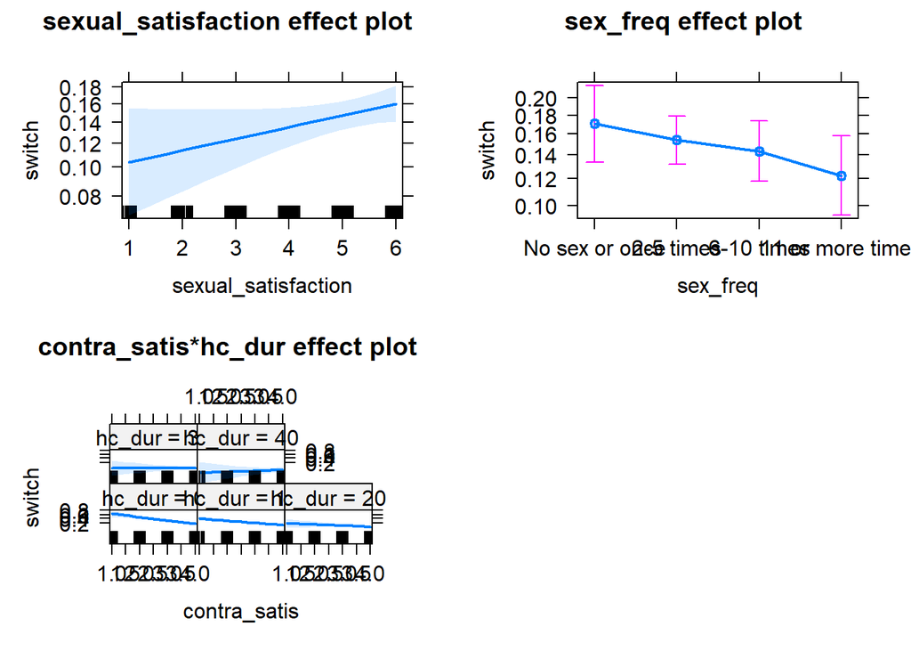

```r
plot(allEffects(R3_sa_m3))
```

###3.3 Model 4: including directly with contraceptive method associated predictors

DURATION and satisfaction!

```r
#filter for first measurement occasion
length(unique(cccu_R3_s$CASEID))
```

```
## [1] 1224
```

```r
cccu_R3_SA_sens = cccu_R3_s %>%
  group_by(CASEID) %>%
  arrange(WAVE) %>%
  mutate(count = row_number()) %>%
  ungroup()

cccu_R3_SA_sens = cccu_R3_SA_sens %>%
  filter(count == 1)

table(cccu_R3_SA_sens$WAVE)
```

```
##
##   t1   t2   t3   t4
## 1032  134   58    0
```

```r
#repeating model 3 as linear model
R3_sa_m3_lm <- glm(switch ~ contra_satis* hc_dur  +  sexual_satisfaction +  sex_freq, family = binomial, data = cccu_R3_SA_sens)

summary(R3_sa_m3_lm)
```

```
##
## Call:
## glm(formula = switch ~ contra_satis * hc_dur + sexual_satisfaction +
##     sex_freq, family = binomial, data = cccu_R3_SA_sens)
##
## Deviance Residuals:
##     Min       1Q   Median       3Q      Max
## -1.6607  -0.6611  -0.5523  -0.4392   2.7917
##
## Coefficients:
##                          Estimate Std. Error z value  Pr(>|z|)
## (Intercept)               1.18396    0.64988   1.822    0.0685 .
## contra_satis             -0.67216    0.16880  -3.982 0.0000683 ***
## hc_dur                   -0.16660    0.10207  -1.632    0.1026
## sexual_satisfaction       0.11973    0.06849   1.748    0.0805 .
## sex_freq2-5 times        -0.46566    0.21284  -2.188    0.0287 *
## sex_freq6-10 times       -0.42688    0.23561  -1.812    0.0700 .
## sex_freq11 or more times -0.64627    0.26454  -2.443    0.0146 *
## contra_satis:hc_dur       0.02525    0.02818   0.896    0.3703
## ---
## Signif. codes:  0 '***' 0.001 '**' 0.01 '*' 0.05 '.' 0.1 ' ' 1
##
## (Dispersion parameter for binomial family taken to be 1)
##
##     Null deviance: 1194.4  on 1223  degrees of freedom
## Residual deviance: 1126.1  on 1216  degrees of freedom
## AIC: 1142.1
##
## Number of Fisher Scoring iterations: 4
```

```r
confint(R3_sa_m3_lm, method = "Wald", level = .997)
```

```
##                                0.2 %     99.8 %
## (Intercept)              -0.73654768  3.1444099
## contra_satis             -1.18495440 -0.1760055
## hc_dur                   -0.48102829  0.1290766
## sexual_satisfaction      -0.07895040  0.3288680
## sex_freq2-5 times        -1.09205911  0.1761647
## sex_freq6-10 times       -1.12643779  0.2775928
## sex_freq11 or more times -1.44220678  0.1354384
## contra_satis:hc_dur      -0.05763431  0.1107905
```

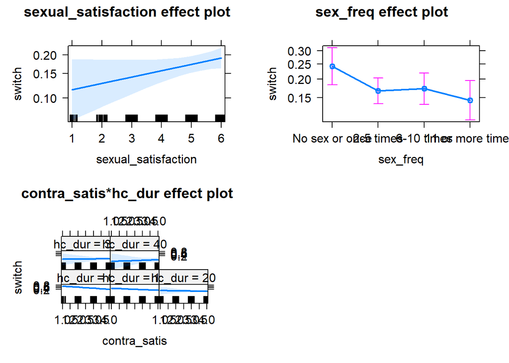

```r
plot(allEffects(R3_sa_m3_lm))
```

```r
#model 4 as linear model (did not converge otherwise)

R3_sa_m4_lm <- glm(switch ~ contra_satis*hc_dur +  sexual_satisfaction +   sex_freq + AGE + DEGREE_recode + POVRATE + HLTHPROB_recode + MEDPROB_recode + GAPINS_recode +
              TYPEINS_recode + NKIDS_t1 +  pregnant_between_waves + had_baby_between_waves+ Avoid_r + FEELPG_recode +
              rel_dur_factor,
            family = binomial,
            data = cccu_R3_SA_sens)

summary(R3_sa_m4_lm)
```

```
##
## Call:
## glm(formula = switch ~ contra_satis * hc_dur + sexual_satisfaction +
##     sex_freq + AGE + DEGREE_recode + POVRATE + HLTHPROB_recode +
##     MEDPROB_recode + GAPINS_recode + TYPEINS_recode + NKIDS_t1 +
##     pregnant_between_waves + had_baby_between_waves + Avoid_r +
##     FEELPG_recode + rel_dur_factor, family = binomial, data = cccu_R3_SA_sens)
##
## Deviance Residuals:
##     Min       1Q   Median       3Q      Max
## -1.6741  -0.6426  -0.4733  -0.3154   3.0658
##
## Coefficients:
##                                                   Estimate  Std. Error z value
## (Intercept)                                      1.9445176   1.6169833   1.203
## contra_satis                                    -0.7283351   0.1790741  -4.067
## hc_dur                                          -0.2026051   0.1092372  -1.855
## sexual_satisfaction                              0.1336356   0.0736111   1.815
## sex_freq2-5 times                               -0.4981992   0.2302648  -2.164
## sex_freq6-10 times                              -0.4160631   0.2537440  -1.640
## sex_freq11 or more times                        -0.7304906   0.2902934  -2.516
## AGE                                              0.0206781   0.0210470   0.982
## DEGREE_recode7th/8th grade                       0.4809160   1.7026293   0.282
## DEGREE_recode9th grade                         -14.2608473 454.6925096  -0.031
## DEGREE_recode10th grade                          1.3395159   1.4229618   0.941
## DEGREE_recode11th grade                         -0.6643756   1.6364774  -0.406
## DEGREE_recode12th grade / no diploma             0.6548045   1.3865256   0.472
## DEGREE_recodehigh school diploma or equivalent   0.3876042   1.2338669   0.314
## DEGREE_recodesome college, no degree             0.4513109   1.2259390   0.368
## DEGREE_recodeassociate degree                   -0.2799302   1.2482285  -0.224
## DEGREE_recodebachelors degree                    0.3209604   1.2239736   0.262
## DEGREE_recodemasters degree                      0.3570347   1.2389343   0.288
## DEGREE_recodeprofessional or doctoral degree     0.4376793   1.3110692   0.334
## POVRATE                                         -0.0004158   0.0003938  -1.056
## HLTHPROB_recodeYes                               0.1574980   0.2064733   0.763
## MEDPROB_recodeYes                               -0.2214304   0.2771180  -0.799
## GAPINS_recodeYes                                -0.0533209   0.4056589  -0.131
## TYPEINS_recodeYes                               -0.0627257   0.4659250  -0.135
## NKIDS_t11                                       -0.0469966   0.2293950  -0.205
## NKIDS_t12                                        0.1914711   0.2617202   0.732
```

[output cut: 44 more lines]

```
## rel_dur_factor0q-25q                                 0.1895
## rel_dur_factor26q-50q                                0.3940
## rel_dur_factor51q-75q                                0.1853
## rel_dur_factor76q-100q                               0.9661
## contra_satis:hc_dur                                  0.2263
## ---
## Signif. codes:  0 '***' 0.001 '**' 0.01 '*' 0.05 '.' 0.1 ' ' 1
##
## (Dispersion parameter for binomial family taken to be 1)
##
##     Null deviance: 1194.4  on 1223  degrees of freedom
## Residual deviance: 1037.4  on 1187  degrees of freedom
## AIC: 1111.4
##
## Number of Fisher Scoring iterations: 14
```

```r
confint(R3_sa_m4_lm, method = "Wald", level = .997)
```

[output not shown]

[output cut: 26 more lines]

[output not shown]

[output not shown]

[output cut: 164 more lines]

[output not shown]

```
##                                                         0.2 %         99.8 %
## (Intercept)                                      -4.245740513   6.5042118815
## contra_satis                                     -1.270079553  -0.1995491696
## hc_dur                                           -0.537228228   0.1152008223
## sexual_satisfaction                              -0.080503736   0.3577829753
## sex_freq2-5 times                                -1.177584192   0.1942494637
## sex_freq6-10 times                               -1.170104136   0.3415716850
## sex_freq11 or more times                         -1.605615994   0.1251789009
## AGE                                              -0.042626522   0.0826745511
## DEGREE_recode7th/8th grade                       -5.763905970   6.7111641105
## DEGREE_recode9th grade                         -257.426428215 -39.9461975362
## DEGREE_recode10th grade                          -2.598590634   7.2458743894
## DEGREE_recode11th grade                          -6.792975232   5.4584628171
## DEGREE_recode12th grade / no diploma             -3.145789597   6.5094199698
## DEGREE_recodehigh school diploma or equivalent   -2.870801586   6.0436339952
## DEGREE_recodesome college, no degree             -2.776029350   6.0990246520
## DEGREE_recodeassociate degree                    -3.590814331   5.3936741402
## DEGREE_recodebachelors degree                    -2.906532839   5.9647711908
## DEGREE_recodemasters degree                      -2.923439674   6.0180607336
## DEGREE_recodeprofessional or doctoral degree     -3.108656358   6.1880548827
## POVRATE                                          -0.001623035   0.0007242669
## HLTHPROB_recodeYes                               -0.471782648   0.7584700178
## MEDPROB_recodeYes                                -1.093321867   0.5650452649
## GAPINS_recodeYes                                 -1.401431871   1.0629006056
## TYPEINS_recodeYes                                -1.549843710   1.2680564240
## NKIDS_t11                                        -0.743150040   0.6227665272
## NKIDS_t12                                        -0.597491044   0.9607279884
## NKIDS_t13                                        -1.750934590   0.9306221735
## NKIDS_t14 or more                                -1.391747791   2.2632714575
## pregnant_between_wavesYes                        -2.517763098   2.6024036144
## had_baby_between_wavesYes                        -3.155828687   2.5697508043
## Avoid_r                                          -0.542376327  -0.1578070260
## FEELPG_recode                                    -0.144466186   0.2293740299
## rel_dur_factor0q-25q                             -0.391967698   1.0113216715
## rel_dur_factor26q-50q                            -0.521121966   0.9376741449
## rel_dur_factor51q-75q                            -0.459748729   1.1881999280
## rel_dur_factor76q-100q                           -1.084269270   1.0244537337
## contra_satis:hc_dur                              -0.052060396   0.1269272840
```

[figure not shown]

```r
plot(allEffects(R3_sa_m4_lm))
```

###R3_SA: Average marginal effects

####sa_m2

```r
#average marginal effect
ame <- marginaleffects(R3_sa_m2)
summary(ame)
```

```
##           Term    Effect Std. Error z value        Pr(>|z|)     2.5 %    97.5 %
## 1 contra_satis -0.061745   0.010602  -5.824 0.0000000057447 -0.082524 -0.040966
## 2       hc_dur -0.006497   0.001211  -5.365 0.0000000809846 -0.008871 -0.004124
##
## Model type:  glmerMod
## Prediction type:  response
```

####sa_m3

```r
#average marginal effect
ame <- marginaleffects(R3_sa_m3)
summary(ame)
```

```
##                  Term                          Contrast    Effect Std. Error
## 1        contra_satis                             dY/dX -0.063570   0.010685
## 2              hc_dur                             dY/dX -0.006409   0.001211
## 3 sexual_satisfaction                             dY/dX  0.012807   0.007004
## 4            sex_freq        2-5 times - No sex or once -0.017020   0.024032
## 5            sex_freq       6-10 times - No sex or once -0.027682   0.026034
## 6            sex_freq 11 or more times - No sex or once -0.049711   0.027547
##   z value        Pr(>|z|)      2.5 %    97.5 %
## 1 -5.9495 0.0000000026891 -0.0845118 -0.042628
## 2 -5.2930 0.0000001203530 -0.0087828 -0.004036
## 3  1.8285        0.067476 -0.0009209  0.026535
## 4 -0.7083        0.478788 -0.0641216  0.030081
## 5 -1.0633        0.287643 -0.0787076  0.023344
## 6 -1.8046        0.071141 -0.1037030  0.004281
##
## Model type:  glmerMod
## Prediction type:  response
```

####sa_m4

```r
#average marginal effect
ame <- marginaleffects(R3_sa_m3_lm)
summary(ame)
```

```
##                  Term                          Contrast   Effect Std. Error
## 1        contra_satis                             dY/dX -0.07583   0.014914
## 2              hc_dur                             dY/dX -0.01169   0.002667
## 3 sexual_satisfaction                             dY/dX  0.01737   0.009912
## 4            sex_freq        2-5 times - No sex or once -0.07469   0.035837
## 5            sex_freq       6-10 times - No sex or once -0.06915   0.039035
## 6            sex_freq 11 or more times - No sex or once -0.09886   0.040620
##   z value      Pr(>|z|)     2.5 %    97.5 %
## 1  -5.085 0.00000036835 -0.105060 -0.046600
## 2  -4.381 0.00001179529 -0.016915 -0.006459
## 3   1.752      0.079700 -0.002057  0.036797
## 4  -2.084      0.037150 -0.144927 -0.004449
## 5  -1.772      0.076472 -0.145658  0.007355
## 6  -2.434      0.014939 -0.178475 -0.019249
##
## Model type:  glm
## Prediction type:  response
```

```r
#average marginal effect
ame <- marginaleffects(R3_sa_m4_lm)
summary(ame)
```

```
##                      Term                                          Contrast
## 1            contra_satis                                             dY/dX
## 2                  hc_dur                                             dY/dX
## 3     sexual_satisfaction                                             dY/dX
## 4                sex_freq                        2-5 times - No sex or once
## 5                sex_freq                       6-10 times - No sex or once
## 6                sex_freq                 11 or more times - No sex or once
## 7                     AGE                                             dY/dX
## 8           DEGREE_recode                     7th/8th grade - 5th/6th grade
## 9           DEGREE_recode                         9th grade - 5th/6th grade
## 10          DEGREE_recode                        10th grade - 5th/6th grade
## 11          DEGREE_recode                        11th grade - 5th/6th grade
## 12          DEGREE_recode           12th grade / no diploma - 5th/6th grade
## 13          DEGREE_recode high school diploma or equivalent - 5th/6th grade
## 14          DEGREE_recode           some college, no degree - 5th/6th grade
```

[output cut: 60 more lines]